# Experimental Identification of Physically Feasible Dynamic Parameters of General Robot using LMI–SDP Techniques

*Experimental code and data associated with the paper:*

**Cristóvão D. Sousa and Rui Cortesão, "Physical feasibility of robot base inertial parameter identification: A linear matrix inequality approach," The International Journal of Robotics Research, vol. 33, no. 6, pp. 931–944, May. 2014, doi: 10.1177/0278364913514870**

[Postprint availabe from ResearchGate](http://www.researchgate.net/publication/262483999_Physical_feasibility_of_robot_base_inertial_parameter_identification_A_linear_matrix_inequality_approach)

## Authors

- Cristóvão D. Sousa, crisjss@gmail.com
- Rui Cortesão, cortesao@isr.uc.pt

## Research Notebook

The research is done in [Python](http://www.python.org/) within an [IPython notebook](http://ipython.org/notebook.html) (the *General Robot Dynamic Parameter Identification.ipynb* file). Data is in *data* folder. Additional Python support code is in *support_funcs* folder.

## How to run the code

- clone the git repository (it contains code and data)
- open the *General Robot Dynamic Parameter Identification.ipynb* notebook with [IPython](http://ipython.org/)
- edit and run the code

Dependencies:

- [Python](http://www.python.org/)
- [IPython](http://ipython.org/)
- [SymPy](http://sympy.org/)
- [Numpy](http://www.numpy.org/)
- [SciPy](http://www.scipy.org/)
- SymPyBotics
- PyLMI-SDP

## Questions & Feedback

Feel free to contact the authors at crisjss@gmail.com

## License

Copyright (c) 2013, Cristóvão Duarte Sousa, Rui Cortesão

All rights reserved.

This work is licensed under a [Creative Commons Attribution-NonCommercial-ShareAlike 4.0 International License](http://creativecommons.org/licenses/by-nc-sa/4.0/)

# Initializations

```python
%load_ext autoreload
%autoreload 1
%aimport support_funcs.regr_data_proc

datafolder = "data/"
tmpfolder = "tmp/"

# f=0.05,因此周期是1/0.05=20秒，这个值会影响激励轨迹的 wf 这个参数，这个频率是计算傅里叶级数的时候的基频
base_freq = 0.05
# 机器人名称
robot_name = "franka"
# 实际机器人激励轨迹采样频率
real_robot_trajectory_sampling_rate=1000.0
# 绘制一个周期内机器人采样原始数据个数
raw_data_num = int(1/base_freq*real_robot_trajectory_sampling_rate)
# 绘制验证n个周期机器人辨识结果数据个数
n = 2
valid_data_num = int(n*raw_data_num)
```

```python
from sympy import init_printing
init_printing()

%pylab inline
```

# 1 - Robot Model

```python
import sympybotics
```

#### Robot Definition

```python
# xMate7 pro robot
# rbtdef = sympybotics.RobotDef(robot_name,
#             [(0,       0,      0.404, "q"),
#              ("-pi/2", 0,          0, "q"),
#              ("pi/2",  0,     0.4375, "q"),
#              ("-pi/2", 0,          0, "q"),
#              ("pi/2",  0,     0.4125, "q"),
#              ("-pi/2", 0,          0, "q"),
#              ("pi/2",  0,     0.2755, "q")],
#             dh_convention="modified")   # # (alpha, a, d, theta)

# # franka panda robot
# rbtdef = sympybotics.RobotDef(robot_name,
#             [(0,             0,      0.333,   "q"),
#              ("-pi/2",       0,          0,   "q"),
#              ("pi/2",        0,      0.316,   "q"),
#              ("pi/2",   0.0825,          0,   "q"),
#              ("-pi/2", -0.0825,      0.384,   "q"),
#              ("pi/2",        0,          0,   "q"),
# #              ("pi/2",    0.088,          0,   "q")],
#              ("pi/2",    0.088,      0.107,   "q")],
#             dh_convention="modified")   # # (alpha, a, d, theta)

# # franka panda robot
rbtdef = sympybotics.RobotDef(robot_name,
            [(0,             0,      0.333,   "q"),
             ("-pi/2",       0,          0,   "q"),
             ("pi/2",        0,      0.316,   "q"),
             ("pi/2",   0.0825,          0,   "q"),
             ("-pi/2", -0.0825,      0.384,   "q"),
             ("pi/2",        0,          0,   "q"),
             ("pi/2",    0.088,          0,   "q")],
            dh_convention="modified")   # # (alpha, a, d, theta)

# rbtdef.frictionmodel = {}
rbtdef.frictionmodel = {'Coulomb', 'viscous'}
# rbtdef.driveinertiamodel = 'simplified'
```

#### Model Generation

```python
%time rbt = sympybotics.RobotDynCode(rbtdef)
%time rbt.calc_base_parms()

M = sympybotics.robotcodegen.robot_code_to_func('c', rbt.M_code, 'M', 'get_'+robot_name+'_M', rbt.rbtdef)
c = sympybotics.robotcodegen.robot_code_to_func('c', rbt.c_code, 'c', 'get_'+robot_name+'_c', rbt.rbtdef)
g = sympybotics.robotcodegen.robot_code_to_func('c', rbt.g_code, 'g', 'get_'+robot_name+'_g', rbt.rbtdef)
f = sympybotics.robotcodegen.robot_code_to_func('c', rbt.f_code, 'f', 'get_'+robot_name+'_f', rbt.rbtdef)
invdyn = sympybotics.robotcodegen.robot_code_to_func('c', rbt.invdyn_code, 'invdyn', 'get_'+robot_name+'_invdyn', rbt.rbtdef)


data = open("MCG_model/result.cpp", 'w+')
data.write(str(rbt.dyn.dynparms) + '\n')
data.write(str(M) + '\n')
data.write(str(c) + '\n')
data.write(str(g) + '\n')
data.write(str(f) + '\n')
data.write(str(invdyn) + '\n')

data.close()
```

```
CPU times: user 5.95 s, sys: 110 ms, total: 6.06 s
Wall time: 6 s
CPU times: user 11.9 s, sys: 317 ms, total: 12.3 s
Wall time: 4.83 s
```

```python
import pickle
with open(tmpfolder + "robotmodels/"+robot_name +".pkl", 'wb') as file:
    pickle.dump( rbt, file )
```

## Base Dynamic Parameters

```python
import pickle
with open(tmpfolder +  "robotmodels/"+robot_name +".pkl", 'rb' ) as file:
          rbt = pickle.load( file )
```

```python
rbt.dyn.n_dynparms, rbt.dyn.n_base
```

```
(84, 57)
```

```python
rbt.dyn.baseparms.n()
```

```
Matrix([
[                                                                                                        L_1zz + L_2yy],
[                                                                                                                 fv_1],
[                                                                                                                 fc_1],
[L_2xx - L_2yy + L_3yy + 0.632*l_3z + 0.099856*m_3 + 0.10666225*m_4 + 0.10666225*m_5 + 0.10666225*m_6 + 0.10666225*m_7],
[                                                                                                                L_2xy],
[                                                                                                                L_2xz],
[                                                                                                                L_2yz],
[        L_2zz + L_3yy + 0.632*l_3z + 0.099856*m_3 + 0.10666225*m_4 + 0.10666225*m_5 + 0.10666225*m_6 + 0.10666225*m_7],
[                                                                                                                 l_2x],
[                                              l_2y - l_3z - 0.316*m_3 - 0.316*m_4 - 0.316*m_5 - 0.316*m_6 - 0.316*m_7],
[                                                                                                                 fv_2],
[                                                                                                                 fc_2],
[                                                                               L_3xx - L_3yy + L_4yy - 0.00680625*m_4],
[                                                                                                  L_3xy + 0.0825*l_4z],
[                                                                                                                L_3xz],
[                                                                                                                L_3yz],
[                                       L_3zz + L_4yy + 0.00680625*m_4 + 0.0136125*m_5 + 0.0136125*m_6 + 0.0136125*m_7],
[                                                             l_3x + 0.0825*m_4 + 0.0825*m_5 + 0.0825*m_6 + 0.0825*m_7],
[                                                                                                          l_3y - l_4z],
[                                                                                                                 fv_3],
[                                                                                                                 fc_3],
[                                L_4xx - L_4yy + L_5yy + 0.768*l_5z + 0.14064975*m_5 + 0.14064975*m_6 + 0.14064975*m_7],
[                                                        L_4xy + 0.0825*l_5z + 0.03168*m_5 + 0.03168*m_6 + 0.03168*m_7],
[                                                                                                                L_4xz],
[                                                                                                                L_4yz],
[                                        L_4zz + L_5yy + 0.768*l_5z + 0.15426225*m_5 + 0.15426225*m_6 + 0.15426225*m_7],
[                                                                          l_4x - 0.0825*m_5 - 0.0825*m_6 - 0.0825*m_7],
[                                                                      l_4y + l_5z + 0.384*m_5 + 0.384*m_6 + 0.384*m_7],
[                                                                                                                 fv_4],
[                                                                                                                 fc_4],
[                                                                                 L_5xx - L_5yy + L_6yy + 0.007744*m_7],
[                                                                                                                L_5xy],
[                                                                                                                L_5xz],
[                                                                                                                L_5yz],
[                                                                                         L_5zz + L_6yy + 0.007744*m_7],
[                                                                                                                 l_5x],
[                                                                                                          l_5y - l_6z],
```

[output cut: 20 more lines]

# 2 - Excited Trajectory Optimization

```python
import pickle
with open(tmpfolder +  "robotmodels/"+robot_name +".pkl", 'rb' ) as file:
          rbt = pickle.load( file )
```

```python
from trajectory_optimization import TrajOptimizer
from trajectory_optimization import TrajPlotter
from numpy import deg2rad

trajectory_folder =  'data/trajectories/'

fourier_order = 5

joint_constraints = []

# 注意修改初始关节角变量，这里有我使用的两个合适的
# franka：qIni = np.array([deg2rad(0), deg2rad(30), deg2rad(0), deg2rad(-90), deg2rad(0), deg2rad(150), deg2rad(0)])
# xMate7：qIni = np.array([0.0, np.pi/6, 0.0, np.pi/3, 0.0, np.pi/2, 0.0])

# xMate7 pro robot 关节约束[关节序号，位置约束，速度约束，加速度约束],
joint_constraints = [(1, deg2rad(-165), deg2rad(165), -2.175, 2.175, -15, 15),
                     (2, deg2rad(-115), deg2rad(115), -2.175, 2.175, -7.5, 7.5),
                     (3, deg2rad(-165), deg2rad(165), -2.175, 2.175, -10, 10),
                     (4, deg2rad(-115), deg2rad(115), -2.175, 2.175, -10, 10),
                     (5, deg2rad(-165), deg2rad(165), -2.610, 2.610, -15, 15),
                     (6, deg2rad(-115), deg2rad(115), -2.610, 2.610, -15, 15),
                     (7, deg2rad(-355), deg2rad(355), -2.610, 2.610, -20, 20)]

# franka panda robot
# joint_constraints = [(1, deg2rad(-160),  deg2rad(160),  -2,         2,  -5, 5),
#                      (2, deg2rad(-95),   deg2rad(95),   -2,         2,  -5, 5),
#                      (3, deg2rad(-160),  deg2rad(160),  -2,         2,  -5, 5),
#                      (4, deg2rad(-170),  deg2rad(-15),  -2,         2,  -5, 5),
#                      (5, deg2rad(-160),  deg2rad(160),  -2,         2,  -5, 5),
#                      (6, deg2rad(10),     deg2rad(209),  -2,         2,  -5, 5),
#                      (7, deg2rad(-160),  deg2rad(160),  -2,         2,  -5, 5)]

# # franka panda robot
# joint_constraints = [(1, deg2rad(-160),  deg2rad(160),  -2,         2,  -15, 15),
#                      (2, deg2rad(-95),   deg2rad(95),   -2,         2,  -7.5, 7.5),
#                      (3, deg2rad(-160),  deg2rad(160),  -2,         2,  -10, 10),
#                      (4, deg2rad(-170),  deg2rad(-15),  -2,         2,  -12.5, 12.5),
#                      (5, deg2rad(-160),  deg2rad(160),  -2,         2,  -15, 15),
#                      (6, deg2rad(10),     deg2rad(209),  -2,         2,  -20, 20),
#                      (7, deg2rad(-160),  deg2rad(160),  -2,         2,  -20, 20)]

# # franka panda robot
# joint_constraints = [(1, deg2rad(-160),  deg2rad(160),  -1.8,         1.8,  -15, 15),
#                      (2, deg2rad(-95),   deg2rad(95),   -1.8,         1.8,  -7.5, 7.5),
#                      (3, deg2rad(-160),  deg2rad(160),  -1.8,         1.8,  -10, 10),
#                      (4, deg2rad(-170),  deg2rad(-15),  -1.8,         1.8,  -12.5, 12.5),
#                      (5, deg2rad(-160),  deg2rad(160),  -1.8,         1.8,  -15, 15),
#                      (6, deg2rad(10),     deg2rad(209), -1.8,         1.8,  -20, 20),
#                      (7, deg2rad(-160),  deg2rad(160),  -1.8,         1.8,  -20, 20)]

traj_optimizer = TrajOptimizer(rbt, fourier_order, base_freq,
                               joint_constraints=joint_constraints)

traj_optimizer.x_result = np.load(trajectory_folder+robot_name+"_opt_x.npy")
# traj_optimizer.optimize()
```

```
dof_num: 7
joint constraint number: 42
cartesian constraint number: 0
constraint number: 42
frames_constrained: []
```

## plot excited trajectory

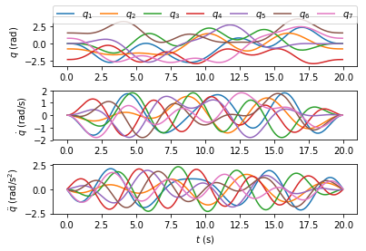

```python
# %matplotlib qt

traj_plotter = TrajPlotter(traj_optimizer.fourier_traj,traj_optimizer.frame_traj,
                           traj_optimizer.const_frame_ind)
traj_plotter.plot_desired_traj(traj_optimizer.x_result, trajectory_folder)
```

## save trajectory

```python
from utils import save_data, load_data

trajectory_name = robot_name

dof_order_bf_x_norm = (traj_optimizer.fourier_traj.dof, fourier_order,
                       base_freq, traj_optimizer.x_result, [])
save_data(trajectory_folder, trajectory_name, dof_order_bf_x_norm)

freq = 50
tf = 105 # including 5 seconds' prestable time
traj_optimizer.make_traj_csv(trajectory_folder, trajectory_name, freq, tf)


# save as .npy format in order to skip the optimizer
np.save(trajectory_folder+robot_name+"_opt_x.npy", traj_optimizer.x_result)

# save as .txt format for the robot
opt_x = [0]*traj_optimizer.fourier_traj.dof*(2*fourier_order+1)
for i in range(traj_optimizer.fourier_traj.dof):
    opt_x[i*11] = traj_optimizer.x_result.tolist()[i*11+1]
    opt_x[i*11+1] = traj_optimizer.x_result.tolist()[i*11+6]
    opt_x[i*11+2] = traj_optimizer.x_result.tolist()[i*11+2]
    opt_x[i*11+3] = traj_optimizer.x_result.tolist()[i*11+7]
    opt_x[i*11+4] = traj_optimizer.x_result.tolist()[i*11+3]
    opt_x[i*11+5] = traj_optimizer.x_result.tolist()[i*11+8]
    opt_x[i*11+6] = traj_optimizer.x_result.tolist()[i*11+4]
    opt_x[i*11+7] = traj_optimizer.x_result.tolist()[i*11+9]
    opt_x[i*11+8] = traj_optimizer.x_result.tolist()[i*11+5]
    opt_x[i*11+9] = traj_optimizer.x_result.tolist()[i*11+10]
    opt_x[i*11+10] = traj_optimizer.x_result.tolist()[i*11+0]

# list_txt(path=trajectory_folder+'opt_x.txt', list=opt_x)
f1 = open(trajectory_folder+robot_name+'_opt_x.txt','w')
for j in opt_x:
    f1.write(str(j)+'\n')
f1.close()
q, dq, ddq = traj_optimizer.fourier_traj.fourier_base_x2q(traj_optimizer.x_result)
q[0]
```

```
array([-6.18795214e-06, -7.85389009e-01, -5.19010444e-06, -2.35619204e+00,
       -8.56277998e-07,  1.57078817e+00,  7.85390460e-01])
```

## display trajectory param

```python
from IPython.display import HTML, display
import tabulate

table = []
table.append(["joint", 'qo'] +
             ["a"+str(i+1) for i in range(fourier_order)] +
             ["b"+str(i+1) for i in range(fourier_order)])
for i in range(traj_optimizer.fourier_traj.dof):
    line = []
    line.append(rbt.rbtdef.q[i])
    line += np.round(traj_optimizer.x_result[i*(1 + fourier_order*2): (i+1)*(1 + fourier_order*2)], 4).tolist()
    table.append(line)

display(HTML(tabulate.tabulate(table, tablefmt='html')))
```

| joint | qo | a1 | a2 | a3 | a4 | a5 | b1 | b2 | b3 | b4 | b5 |
| --- | --- | --- | --- | --- | --- | --- | --- | --- | --- | --- | --- |
| q1 | -0.4968 | -0.419 | -0.2982 | -0.7692 | 0.88 | 0.6063 | -0.2099 | 0.2328 | -0.3491 | 0.2461 | -0.0385 |
| q2 | -0.399 | -0.3212 | -0.2211 | 0.1156 | 0.4058 | 0.0209 | 0.0989 | -0.1847 | 0.7123 | -0.5324 | 0.0526 |
| q3 | 0.3773 | -0.1212 | 0.0939 | -0.0189 | 0.2466 | -0.2003 | 0.2962 | -0.0146 | -0.3814 | -0.8701 | 0.8715 |
| q4 | -1.771 | -0.0103 | 0.3887 | 0.2936 | 0.2093 | -0.8814 | 0.0334 | 0.2343 | 0.0887 | 0.3829 | -0.4599 |
| q5 | 0.0383 | -0.2554 | 0.6233 | -0.1914 | -0.1183 | -0.0582 | 0.1236 | -0.5894 | 0.4317 | 0.5432 | -0.4825 |
| q6 | 1.5406 | 0.0197 | -0.2342 | -0.0942 | -0.1589 | 0.4676 | -0.3043 | 0.274 | 0.8338 | -0.1141 | -0.4577 |
| q7 | -0.6768 | -0.5825 | -0.391 | 0.2461 | 0.123 | 0.6045 | -0.5036 | 0.1939 | -0.168 | -0.2385 | 0.3148 |

# 3 - Regression Data Processing

```python
import os
import pickle
import math
import sympy
import numpy
import sympybotics
```

```python
with open(tmpfolder +  "robotmodels/"+robot_name +".pkl", 'rb' ) as file:
          rbt = pickle.load( file )
```

### Data Load

```python
parms_traj = 'traj1'
```

```python
from support_funcs.regr_data_proc import load_trajectory_data

training_results_data_file = datafolder +'recdata/' + robot_name+'_'+parms_traj+'_results.csv'

trajectory_sampling_rate = real_robot_trajectory_sampling_rate    # 实际机器人数据采样频率，用于计算时间
t_raw, q_raw, dq_raw, ddq_raw, tau_raw = load_trajectory_data(training_results_data_file,
                                                                   trajectory_sampling_rate)
t_raw.shape
```

```
(<type 'numpy.ndarray'>, (40001, 28))
```

```
(40001,)
```

### Some Plots

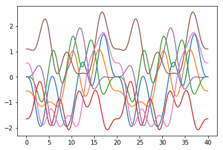

```python
from matplotlib import pyplot as plt
plt.close()

# for d in range(rbt.dof):
#     co_num = str(d + 1)
#     plt.plot(t_raw, q_raw[:, d], label=(r"$q_" + co_num +"$"), linestyle= (0, ()))

for i in range(q_raw.shape[1]):
    plt.plot(t_raw,q_raw[:,i])

plt.show()
```

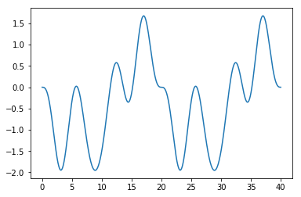

```python
from matplotlib import pyplot as plt
plt.close()

joint = 1
# plt.plot(t_ref+0.20,q_ref[:,joint-1])
plt.plot(t_raw,q_raw[:,joint-1])

plt.show()
```

```python
del t_raw, q_raw, dq_raw,tau_raw
```

### Parameter Load

```python
from utils import save_data, load_data

training_trajectory_name = robot_name


trajectory_folder = datafolder +'trajectories/'
dof, fourier_order, base_freq, traj_optimizer_result, reg_norm_mat = load_data(trajectory_folder,
                                                                               training_trajectory_name)
print("dof: {}".format(dof))
print("Fourier order: {}".format(fourier_order))
print("Base frequency: {}".format(base_freq))
```

```
dof: 7
Fourier order: 5
Base frequency: 0.05
```

### Filter Cut-off Frequency Definition

```python
# times of the highest frequency in the Fourier series
fc_mult = 10.0

fc = base_freq * fourier_order * fc_mult
print("Cut frequency: {}".format(fc))
```

```
Cut frequency: 2.5
```

```python
fc_q = fc
fc_dq = fc
fc_ddq = fc

fc_tau = float('Inf')  # fc

# si = 200
# sf = -200

si = int(3/0.02)
sf = -int(1/0.02)


# si = int(3/0.001)
# sf = -int(1/0.001)
```

### Data Filtering, Differentiation and Regression Data Generation

```python
rec_h = 1.0/real_robot_trajectory_sampling_rate
```

```python
rec_h
```

```
0.001
```

```python
from support_funcs.regr_data_proc import load_trajectory_data, plot_trajectory_data, \
                                            diff_and_filt_data, gen_regr_matrices


def process_regression_data(traj_name):
#     t_raw, q_raw, tau_raw, t_ref, q_ref = read_data(dof=rbt.dof, h=rec_h,
#                                                     rbtlogfile=datafolder + 'recdata/rbtlog_%s.dat'%traj_name,
#                                                     trajreffile=datafolder + 'trajectories/%s.dat'%traj_name)

    training_results_data_file = datafolder +'recdata/' + robot_name+'_%s_results.csv'%traj_name
    trajectory_sampling_rate = real_robot_trajectory_sampling_rate    # 实体机器人运行,记录数据采样频率
    t_raw, q_raw, dq_raw, ddq_raw, tau_raw = load_trajectory_data(training_results_data_file,
                                                                   trajectory_sampling_rate)

    # 原始采集数据滤波
    q, dq, ddq, tau = diff_and_filt_data(dof=rbt.dof, h=rec_h,  q_raw=q_raw, dq_raw=dq_raw, ddq_raw=ddq_raw,
                                         tau_raw=tau_raw,fc_q=fc_q, fc_dq=fc_dq, fc_ddq=fc_ddq, fc_tau=fc_tau)

    # 掐头去尾留中间，可能是因为开始和结束时抖动？
    t_raw = t_raw[si:sf]; q_raw = q_raw[si:sf]; tau_raw = tau_raw[si:sf]
    q = q[si:sf]; dq = dq[si:sf]; ddq = ddq[si:sf]; tau = tau[si:sf]


    t_raw = t_raw - t_raw[0]

    t = numpy.array(range(q.shape[0])) * rec_h

    W, omega, Q1, R1, rho1 = gen_regr_matrices(rbt, q, dq, ddq, tau)

    # t_raw, q_raw, tau_raw是原始采集数据，t, q, dq, ddq, tau是滤波后的数据
    return t_raw, q_raw, tau_raw, t, q, dq, ddq, tau, W, omega, Q1, R1, rho1
```

```python
from support_funcs.utils import _fprint
from support_funcs.regr_data_proc import plot_trajectory_data

for traj in ['traj1', 'traj2', 'traj3']:      #, 'traj4'
    _fprint('>>>>>>>> %s proc <<<<<<<<<'%traj)
    %time t_raw, q_raw, tau_raw, t, q, dq, ddq, tau, W, omega, Q1, R1, rho1 = process_regression_data(traj)

    _fprint(' (cond=%f)'%numpy.linalg.cond(W))

    _fprint('%s save'%traj)

    %time \
    numpy.savez_compressed(tmpfolder + 'procdata/' + traj + '_raw', t=t_raw, q=q_raw, tau=tau_raw);\
    numpy.savez_compressed(tmpfolder + 'procdata/' + traj + '_proc', t=t, q=q, dq=dq, ddq=ddq, tau=tau); \
    numpy.savez_compressed(tmpfolder + 'procdata/' + traj + '_regr', W=W, omega=omega, Q1=Q1, R1=R1, rho1=rho1)

#     plot_trajectory_data(t, q_raw, q, dq, ddq,
#                      tau_raw, tau)

    del t_raw, q_raw, tau_raw, t, q, dq, ddq, tau, W, omega, Q1, R1, rho1
```

```
>>>>>>>> traj1 proc <<<<<<<<<
(<type 'numpy.ndarray'>, (40001, 28))
CPU times: user 24.7 s, sys: 1.03 s, total: 25.8 s
Wall time: 9.66 s
 (cond=82.893864)
traj1 save
CPU times: user 8.74 s, sys: 469 ms, total: 9.21 s
Wall time: 8.73 s
>>>>>>>> traj2 proc <<<<<<<<<
(<type 'numpy.ndarray'>, (40001, 28))
CPU times: user 24.5 s, sys: 984 ms, total: 25.5 s
Wall time: 9.62 s
 (cond=106.808594)
traj2 save
CPU times: user 10.7 s, sys: 592 ms, total: 11.2 s
Wall time: 7.33 s
>>>>>>>> traj3 proc <<<<<<<<<
(<type 'numpy.ndarray'>, (40001, 28))
CPU times: user 19.5 s, sys: 1.03 s, total: 20.6 s
Wall time: 5.7 s
 (cond=175.540090)
traj3 save
CPU times: user 8.76 s, sys: 476 ms, total: 9.23 s
Wall time: 5.14 s
```

### Plot

```python
raw = numpy.load(tmpfolder + 'procdata/traj1_raw.npz')
tau_raw = raw['tau']
q_raw = raw['q']
del raw
proc = numpy.load(tmpfolder + 'procdata/traj1_proc.npz')
t = proc['t']
tau = proc['tau']
q = proc['q']
dq = proc['dq']
del proc
```

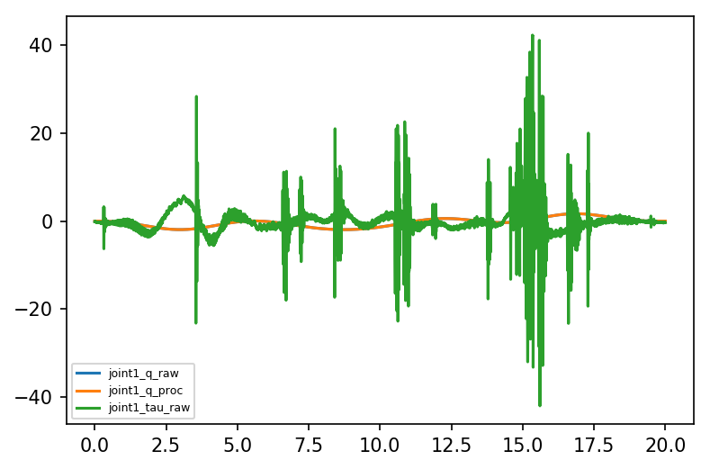

```python
from matplotlib import pyplot as plt
plt.close()

plt.figure(dpi=150)
joint = 1
plt.plot(t[:raw_data_num],q_raw[:,joint-1][:raw_data_num],label='joint'+str(joint)+'_q_raw')
plt.plot(t[:raw_data_num],q[:,joint-1][:raw_data_num],label='joint'+str(joint)+'_q_proc')
#plt.plot(t[:raw_data_num],dq[:,joint-1][:raw_data_num])
plt.plot(t[:raw_data_num],tau_raw[:,joint-1][:raw_data_num],label='joint'+str(joint)+'_tau_raw')
plt.rc('legend', fontsize=6)
plt.legend(loc=3)

plt.show()
```

```python
del t, q, dq, tau, q_raw, tau_raw
```

# 4 - Dynamic Parameter Estimation

```python
import os
import pickle
import sympy
import numpy
import time

import sympybotics
import lmi_sdp

from lmi_sdp import init_lmi_latex_printing
init_lmi_latex_printing()
```

```python
with open(tmpfolder +  "robotmodels/"+robot_name +".pkl", 'rb' ) as file:
          rbt = pickle.load( file )
```

```python
epsilon_safemargin = 1e-30
epsilon_sdptol = 1e-7
```

## LMI Matrix Definitions

```python
dof = rbt.dof

delta = rbt.dyn.dynparms    # 要辨识的全参数集矩阵表达式
n_delta = rbt.dyn.n_dynparms    # 要辨识的全参数集参数数量

beta = rbt.dyn.baseparms.n()    # 最小参数集矩阵表达式
n_beta = rbt.dyn.n_base         # 最小参数集参数数量
beta_symbs = sympy.Matrix([sympy.Symbol('beta'+str(i+1),real=True) for i in range(n_beta)])

delta_d = (rbt.dyn.Pd.T*delta)  # beta中非独立部分
n_delta_d = len(delta_d)

K = rbt.dyn.Pb.T + rbt.dyn.Kd * rbt.dyn.Pd.T

Pb = rbt.dyn.Pb

varchange_dict = dict(zip(Pb.T*delta ,  beta_symbs - ( beta - Pb.T*delta )))
```

```python
from support_funcs.utils import skew, mrepl
from sympy import BlockMatrix, Matrix, eye, Identity
I = Identity
S = skew
```

```python
D_inertia_blocks = []
# `L` is the link inertia tensor computed about the link frame;
# `l` is the link first moment of inertia;
# `m` is the link mass.
for i in range(dof):
    L = rbt.rbtdef.L[i]
    l = rbt.rbtdef.l[i]
    m = rbt.rbtdef.m[i]
    Di = BlockMatrix([[L,    S(l).T],
                      [S(l), I(3)*m]])
    D_inertia_blocks.append(Di.as_explicit())
```

```python
D_inertia_blocks[0]
```

```
Matrix([
[L_1xx, L_1xy, L_1xz,     0,  l_1z, -l_1y],
[L_1xy, L_1yy, L_1yz, -l_1z,     0,  l_1x],
[L_1xz, L_1yz, L_1zz,  l_1y, -l_1x,     0],
[    0, -l_1z,  l_1y,   m_1,     0,     0],
[ l_1z,     0, -l_1x,     0,   m_1,     0],
[-l_1y,  l_1x,     0,     0,     0,   m_1]])
```

```python
F_blocks = []
for i in range(dof):
    if rbt.rbtdef.driveinertiamodel == 'simplified':
        F_blocks.append( Matrix([rbt.rbtdef.Ia[i]]) )
    if 'viscous' in rbt.rbtdef.frictionmodel:
        F_blocks.append( Matrix([rbt.rbtdef.fv[i]]) )
    if 'Coulomb' in rbt.rbtdef.frictionmodel:
        F_blocks.append( Matrix([rbt.rbtdef.fc[i]]) )
```

```python
E_blocks = D_inertia_blocks + F_blocks
```

```python
E_blocks
```

```
[Matrix([
 [L_1xx, L_1xy, L_1xz,     0,  l_1z, -l_1y],
 [L_1xy, L_1yy, L_1yz, -l_1z,     0,  l_1x],
 [L_1xz, L_1yz, L_1zz,  l_1y, -l_1x,     0],
 [    0, -l_1z,  l_1y,   m_1,     0,     0],
 [ l_1z,     0, -l_1x,     0,   m_1,     0],
 [-l_1y,  l_1x,     0,     0,     0,   m_1]]), Matrix([
 [L_2xx, L_2xy, L_2xz,     0,  l_2z, -l_2y],
 [L_2xy, L_2yy, L_2yz, -l_2z,     0,  l_2x],
 [L_2xz, L_2yz, L_2zz,  l_2y, -l_2x,     0],
 [    0, -l_2z,  l_2y,   m_2,     0,     0],
 [ l_2z,     0, -l_2x,     0,   m_2,     0],
 [-l_2y,  l_2x,     0,     0,     0,   m_2]]), Matrix([
 [L_3xx, L_3xy, L_3xz,     0,  l_3z, -l_3y],
 [L_3xy, L_3yy, L_3yz, -l_3z,     0,  l_3x],
 [L_3xz, L_3yz, L_3zz,  l_3y, -l_3x,     0],
 [    0, -l_3z,  l_3y,   m_3,     0,     0],
 [ l_3z,     0, -l_3x,     0,   m_3,     0],
 [-l_3y,  l_3x,     0,     0,     0,   m_3]]), Matrix([
 [L_4xx, L_4xy, L_4xz,     0,  l_4z, -l_4y],
 [L_4xy, L_4yy, L_4yz, -l_4z,     0,  l_4x],
 [L_4xz, L_4yz, L_4zz,  l_4y, -l_4x,     0],
 [    0, -l_4z,  l_4y,   m_4,     0,     0],
 [ l_4z,     0, -l_4x,     0,   m_4,     0],
 [-l_4y,  l_4x,     0,     0,     0,   m_4]]), Matrix([
 [L_5xx, L_5xy, L_5xz,     0,  l_5z, -l_5y],
 [L_5xy, L_5yy, L_5yz, -l_5z,     0,  l_5x],
 [L_5xz, L_5yz, L_5zz,  l_5y, -l_5x,     0],
 [    0, -l_5z,  l_5y,   m_5,     0,     0],
 [ l_5z,     0, -l_5x,     0,   m_5,     0],
 [-l_5y,  l_5x,     0,     0,     0,   m_5]]), Matrix([
 [L_6xx, L_6xy, L_6xz,     0,  l_6z, -l_6y],
 [L_6xy, L_6yy, L_6yz, -l_6z,     0,  l_6x],
 [L_6xz, L_6yz, L_6zz,  l_6y, -l_6x,     0],
 [    0, -l_6z,  l_6y,   m_6,     0,     0],
 [ l_6z,     0, -l_6x,     0,   m_6,     0],
 [-l_6y,  l_6x,     0,     0,     0,   m_6]]), Matrix([
 [L_7xx, L_7xy, L_7xz,     0,  l_7z, -l_7y],
 [L_7xy, L_7yy, L_7yz, -l_7z,     0,  l_7x],
 [L_7xz, L_7yz, L_7zz,  l_7y, -l_7x,     0],
 [    0, -l_7z,  l_7y,   m_7,     0,     0],
 [ l_7z,     0, -l_7x,     0,   m_7,     0],
 [-l_7y,  l_7x,     0,     0,     0,   m_7]]), Matrix([[fv_1]]), Matrix([[fc_1]]), Matrix([[fv_2]]), Matrix([[fc_2]]), Matrix([[fv_3]]), Matrix([[fc_3]]), Matrix([[fv_4]]), Matrix([[fc_4]]), Matrix([[fv_5]]), Matrix([[fc_5]]), Matrix([[fv_6]]), Matrix([[fc_6]]), Matrix([[fv_7]]), Matrix([[fc_7]])]
```

## Change of Variable Space

```python
varchange_dict = dict(zip(Pb.T*delta ,  beta_symbs - ( beta - Pb.T*delta )))
```

```python
EB_blocks = [mrepl(Ei, varchange_dict) for Ei in E_blocks]
EB_blocks
```

```
[Matrix([
 [L_1xx, L_1xy,          L_1xz,     0,  l_1z, -l_1y],
 [L_1xy, L_1yy,          L_1yz, -l_1z,     0,  l_1x],
 [L_1xz, L_1yz, -L_2yy + beta1,  l_1y, -l_1x,     0],
 [    0, -l_1z,           l_1y,   m_1,     0,     0],
 [ l_1z,     0,          -l_1x,     0,   m_1,     0],
 [-l_1y,  l_1x,              0,     0,     0,   m_1]]), Matrix([
 [L_2yy - L_3yy + beta4 - 0.632*l_3z - 0.099856*m_3 - 0.10666225*m_4 - 0.10666225*m_5 - 0.10666225*m_6 - 0.10666225*m_7, beta5,                                                                                                          beta6,                                                             …
 [                                                                                                                beta5, L_2yy,                                                                                                          beta7,                                                             …
 [                                                                                                                beta6, beta7, -L_3yy + beta8 - 0.632*l_3z - 0.099856*m_3 - 0.10666225*m_4 - 0.10666225*m_5 - 0.10666225*m_6 - 0.10666225*m_7, beta10 + l_3z + 0.316*m_3 + 0.316*m_4 + 0.316*m_5 + 0.316*m_…
 [                                                                                                                    0, -l_2z,                                      beta10 + l_3z + 0.316*m_3 + 0.316*m_4 + 0.316*m_5 + 0.316*m_6 + 0.316*m_7,                                                             …
 [                                                                                                                 l_2z,     0,                                                                                                         -beta9,                                                             …
 [                                           -beta10 - l_3z - 0.316*m_3 - 0.316*m_4 - 0.316*m_5 - 0.316*m_6 - 0.316*m_7, beta9,                                                                                                              0,                                                             …
 [L_3yy - L_4yy + beta13 + 0.00680625*m_4,                                       beta14 - 0.0825*l_4z,                                                                           beta15,             0,                                                        l_3z,                                        …
 [                   beta14 - 0.0825*l_4z,                                                      L_3yy,                                                                           beta16,         -l_3z,                                                           0, beta18 - 0.0825*m_4 - 0.0825*m_5 - 0.08…
 [                                 beta15,                                                     beta16, -L_4yy + beta17 - 0.00680625*m_4 - 0.0136125*m_5 - 0.0136125*m_6 - 0.0136125*m_7, beta19 + l_4z, -beta18 + 0.0825*m_4 + 0.0825*m_5 + 0.0825*m_6 + 0.0825*m_7,                                        …
 [                                      0,                                                      -l_3z,                                                                    beta19 + l_4z,           m_3,                                                           0,                                        …
 [                                   l_3z,                                                          0,                      -beta18 + 0.0825*m_4 + 0.0825*m_5 + 0.0825*m_6 + 0.0825*m_7,             0,                                                         m_3,                                        …
```

[output cut: 25 more lines]

## LMI Definitions

```python
from lmi_sdp import LMI_PD, LMI
```

```python
EB_LMIs = list(map(LMI_PD, EB_blocks))
```

```python
EB_LMIs[0]
```

```
Matrix([
[L_1xx, L_1xy,          L_1xz,     0,  l_1z, -l_1y],
[L_1xy, L_1yy,          L_1yz, -l_1z,     0,  l_1x],
[L_1xz, L_1yz, -L_2yy + beta1,  l_1y, -l_1x,     0],
[    0, -l_1z,           l_1y,   m_1,     0,     0],
[ l_1z,     0,          -l_1x,     0,   m_1,     0],
[-l_1y,  l_1x,              0,     0,     0,   m_1]]) > 0
```

```python
EB_LMIs_marg = list(map(lambda lm: LMI(lm, epsilon_safemargin*eye(lm.shape[0])) , EB_blocks))
```

```python
EB_LMIs_marg[0]
```

```
Matrix([
[L_1xx, L_1xy,          L_1xz,     0,  l_1z, -l_1y],
[L_1xy, L_1yy,          L_1yz, -l_1z,     0,  l_1x],
[L_1xz, L_1yz, -L_2yy + beta1,  l_1y, -l_1x,     0],
[    0, -l_1z,           l_1y,   m_1,     0,     0],
[ l_1z,     0,          -l_1x,     0,   m_1,     0],
[-l_1y,  l_1x,              0,     0,     0,   m_1]]) >= Matrix([
[1.0e-30,       0,       0,       0,       0,       0],
[      0, 1.0e-30,       0,       0,       0,       0],
[      0,       0, 1.0e-30,       0,       0,       0],
[      0,       0,       0, 1.0e-30,       0,       0],
[      0,       0,       0,       0, 1.0e-30,       0],
[      0,       0,       0,       0,       0, 1.0e-30]])
```

```python
EB_LMIs_marg[0].canonical()
```

```
Matrix([
[L_1xx - 1.0e-30,           L_1xy,                    L_1xz,             0,          l_1z,         -l_1y],
[          L_1xy, L_1yy - 1.0e-30,                    L_1yz,         -l_1z,             0,          l_1x],
[          L_1xz,           L_1yz, -L_2yy + beta1 - 1.0e-30,          l_1y,         -l_1x,             0],
[              0,           -l_1z,                     l_1y, m_1 - 1.0e-30,             0,             0],
[           l_1z,               0,                    -l_1x,             0, m_1 - 1.0e-30,             0],
[          -l_1y,            l_1x,                        0,             0,             0, m_1 - 1.0e-30]]) >= 0
```

## SDP Solver Interfaces

### [SDPA](http://sdpa.sourceforge.net/)

```python
def sdpa(objf, lmis, variables):
    sdpadat = lmi_sdp.to_sdpa_sparse(objf, lmis, variables)
    with open(tmpfolder + 'sdpa_dat/sdp.dat-s', 'w') as f:
        f.write(sdpadat)

    stdout = !sdpa -ds "$tmpfolder"sdpa_dat/sdp.dat-s -o "$tmpfolder"sdpa_dat/sdpa.out -p "$tmpfolder"sdpa_dat/param.sdpa -pt 2
    print('\n'.join(stdout))

    outfile = !cat "$tmpfolder"sdpa_dat/sdpa.out
    sol = [float(v) for v in outfile[outfile.index('xVec = ') + 1].replace('{', '').replace('}', '').split(',')]
    return numpy.matrix(sol).T
```

### [CSDP](https://projects.coin-or.org/Csdp/)

```python
def csdp(objf, lmis, variables):
    sdpadat = lmi_sdp.to_sdpa_sparse(objf, lmis, variables)
    with open(tmpfolder + 'sdpa_dat/sdp.dat-s', 'w') as f:
        f.write(sdpadat)

    stdout = !cd "$tmpfolder"sdpa_dat; csdp sdp.dat-s csdp.out
    print('\n'.join(stdout))

    outfile = !cat "$tmpfolder"sdpa_dat/csdp.out
    sol = [float(v) for v in outfile[0].split()]
    return numpy.matrix(sol).T
```

### DSDP5

```python
def dsdp5(objf, lmis, variables):
    sdpadat = lmi_sdp.to_sdpa_sparse(objf, lmis, variables)
    with open(tmpfolder + 'sdpa_dat/sdp.dat-s', 'w') as f:
        f.write(sdpadat)

    stdout = !cd "$tmpfolder"sdpa_dat; dsdp5 sdp.dat-s -save dsdp5.out -gaptol $epsilon_sdptol
    print('\n'.join(stdout))

    outfile = !cat "$tmpfolder"sdpa_dat/dsdp5.out
    sol = [float(v) for v in outfile[0].split()]
    return numpy.matrix(sol).T
```

### [DSDP5 through CVXOPT](http://abel.ee.ucla.edu/cvxopt/userguide/coneprog.html#cvxopt.solvers.sdp)

```python
def cvxopt_dsdp5(objf, lmis, variables):
    import cvxopt.solvers
    c, Gs, hs = lmi_sdp.to_cvxopt(objf, lmis, variables)
    cvxopt.solvers.options['DSDP_GapTolerance'] = epsilon_sdptol
    tic = time.time()
    sdpout = cvxopt.solvers.sdp(c, Gs=Gs, hs=hs, solver='dsdp')
    toc = time.time()
    print(sdpout['status'], ('ATT!: \'optimal\' does not necessarlly means feasible'))
    print('Elapsed time: %.2f s'%(toc-tic))
    return numpy.matrix(sdpout['x'])
```

### [CVXOPT CONELP](http://abel.ee.ucla.edu/cvxopt/userguide/coneprog.html#cvxopt.solvers.sdp)

```python
def cvxopt_conelp(objf, lmis, variables):
    import cvxopt.solvers
    c, Gs, hs = lmi_sdp.to_cvxopt(objf, lmis, variables)
    cvxopt.solvers.options['feastol'] = epsilon_sdptol
    tic = time.time()
    sdpout = cvxopt.solvers.sdp(c, Gs=Gs, hs=hs)
    toc = time.time()
    print(sdpout['status'])
    print('Elapsed time: %.2f s'%(toc-tic))
    return numpy.matrix(sdpout['x'])
```

### [Raw SDPA file](http://plato.asu.edu/ftp/sdpa_format.txt)

Can be solved online with a *Semidefinite Programming* solver at [NEOS Solvers](http://www.neos-server.org/neos/solvers/index.html)

```python
def sdpa_file(objf, lmis, variables):
    sdpadat = lmi_sdp.to_sdpa_sparse(objf, lmis, variables)
    with open(tmpfolder + 'sdpa_dat/sdpa_input.dat-s', 'w') as f:
        f.write(sdpadat)

    print("SDPA file saved at: %ssdpa_dat/sdpa_input.dat-s"%tmpfolder)
```

Setting the default SDP solver:

```python
solve_sdp = dsdp5
```

## Method 1:Ordinary Least Squares (OLS)

```python
indentification_traj = 'traj1'
```

```python
regr_mats = numpy.load(tmpfolder + 'procdata/' + indentification_traj + '_regr.npz')
W = numpy.matrix(regr_mats['W'])
omega = numpy.matrix(regr_mats['omega'])
R1 = numpy.matrix(regr_mats['R1'])
rho1 = numpy.matrix(regr_mats['rho1'])
```

```python
omega.shape[0] / rbt.dof
```

```
39801
```

```python
W.shape
```

```
(278607, 57)
```

```python
numpy.linalg.cond(W)
```

```
82.89386402933268
```

```python
%time beta_ols = (R1.T * R1).I * R1.T * rho1
```

```
CPU times: user 76.3 ms, sys: 16 ms, total: 92.3 ms
Wall time: 4.7 ms
```

```python
numpy.savetxt(tmpfolder + 'solutions/'+robot_name+'_' + indentification_traj + '_beta_ols.dat', beta_ols)
```

```python
rho2_norm_sqr = numpy.linalg.norm(omega - W * beta_ols)**2
```

### plot measured and predicted torque

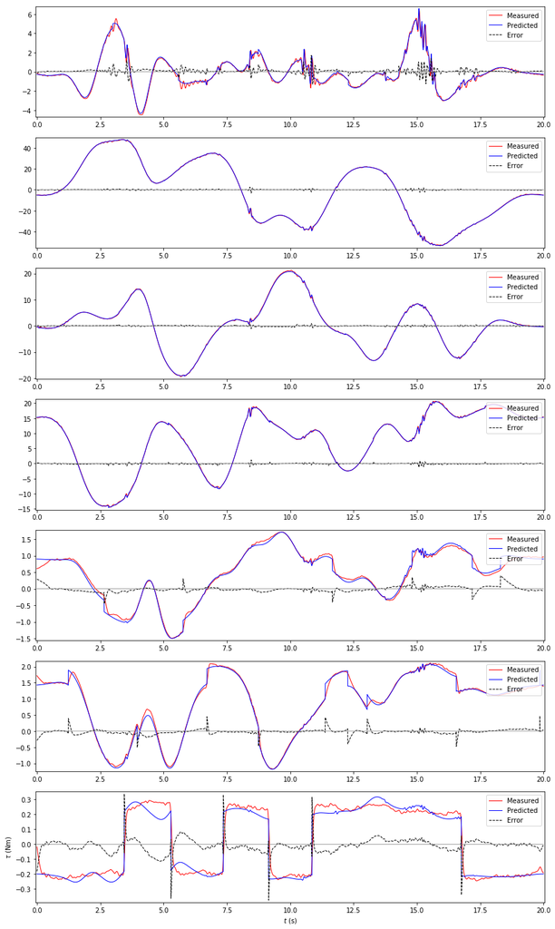

```python
from support_funcs.regr_data_proc import  plot_meas_pred_tau

import matplotlib.pyplot as plt
plt.rcParams['figure.figsize'] = [12,20]

proc = numpy.load(tmpfolder + 'procdata/' + indentification_traj + '_proc.npz')
t = proc['t']
tau = proc['tau']

tau_p = np.zeros(tau.shape)
tau_ps = W.dot(beta_ols)
for i in range(dof):
    tau_p[:, i] = tau_ps[i::dof].flatten()

trajectory_sampling_rate = real_robot_trajectory_sampling_rate
plot_data_num = int(1 / base_freq * trajectory_sampling_rate)

save_fig_path = tmpfolder + '/solutions/fig/'+robot_name+'_ols_result.png'
plot_meas_pred_tau(save_fig_path, t[:plot_data_num], tau[:plot_data_num, :],
                   tau_p[:plot_data_num, :])
```

## Method 2:Weighted Least Square (WLS)

```python
proc = numpy.load(tmpfolder + 'procdata/' + indentification_traj + '_proc.npz')
t = proc['t']
tau = proc['tau']

weight = np.max(tau, axis=0) - np.min(tau, axis=0)
print("weight: ")
print(weight)


# repeat the weight to generate a large vecoter for all the data
weights = 1.0/np.tile(weight, W.shape[0]/weight.shape[0])
```

```
weight:
[ 10.89474533 101.29990015  40.6959838   35.30021823   3.22066263
   3.29276757   0.55079352]
```

```python
weights[0:6]
```

```
array([0.09178737, 0.00987168, 0.02457245, 0.02832844, 0.31049511,
       0.3036959 ])
```

```python
W_wls = np.multiply(W, np.asmatrix(weights).transpose())
omega_wls = np.multiply(omega.T, weights).T
Q1_wls,R1_wls = numpy.linalg.qr(W_wls)
rho1_wls = Q1_wls.T*omega_wls
```

```python
%time beta_wls = (R1_wls.T * R1_wls).I * R1_wls.T * rho1_wls
```

```
CPU times: user 29 ms, sys: 1.33 ms, total: 30.3 ms
Wall time: 1.14 ms
```

```python
numpy.savetxt(tmpfolder + 'solutions/'+robot_name+'_' + indentification_traj + '_beta_wls.dat', beta_wls)
```

```python
rho2_norm_sqr_wls = numpy.linalg.norm(omega_wls - W_wls * beta_wls)**2
```

### plot measured and predicted torque

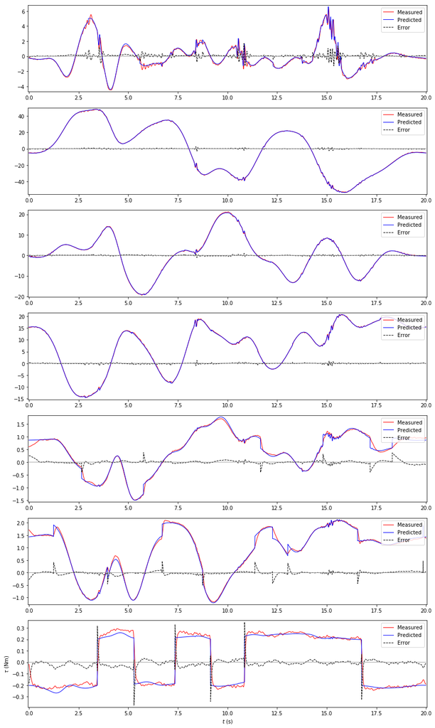

```python
from support_funcs.regr_data_proc import  plot_meas_pred_tau

import matplotlib.pyplot as plt
plt.rcParams['figure.figsize'] = [12,20]

proc = numpy.load(tmpfolder + 'procdata/' + indentification_traj + '_proc.npz')
t = proc['t']
tau = proc['tau']

tau_p = np.zeros(tau.shape)
tau_ps = W.dot(beta_wls)
for i in range(dof):
    tau_p[:, i] = tau_ps[i::dof].flatten()

trajectory_sampling_rate = real_robot_trajectory_sampling_rate
plot_data_num = int(1 / base_freq * trajectory_sampling_rate)
save_fig_path = tmpfolder + 'solutions/fig/'+robot_name+'_wls_result.png'
plot_meas_pred_tau(save_fig_path, t[:plot_data_num], tau[:plot_data_num, :],
                   tau_p[:plot_data_num, :])
```

## Method 3:Feasible Base Parameter Estimation with Ordinary Least Squares (FBPE-OLS)

```python
u = sympy.Symbol('u')
U_beta = BlockMatrix([[Matrix([u]),            (beta_ols - beta_symbs).T],
                 [beta_ols - beta_symbs,                 I(n_beta)]])
U_beta = U_beta.as_explicit()
```

```python
lmis_ols_fbpe = [LMI(U_beta)] + EB_LMIs_marg
```

```python
lmis_ols_fbpe[1]
```

```
Matrix([
[L_1xx, L_1xy,          L_1xz,     0,  l_1z, -l_1y],
[L_1xy, L_1yy,          L_1yz, -l_1z,     0,  l_1x],
[L_1xz, L_1yz, -L_2yy + beta1,  l_1y, -l_1x,     0],
[    0, -l_1z,           l_1y,   m_1,     0,     0],
[ l_1z,     0,          -l_1x,     0,   m_1,     0],
[-l_1y,  l_1x,              0,     0,     0,   m_1]]) >= Matrix([
[1.0e-30,       0,       0,       0,       0,       0],
[      0, 1.0e-30,       0,       0,       0,       0],
[      0,       0, 1.0e-30,       0,       0,       0],
[      0,       0,       0, 1.0e-30,       0,       0],
[      0,       0,       0,       0, 1.0e-30,       0],
[      0,       0,       0,       0,       0, 1.0e-30]])
```

```python
variables_ols_fbpe = [u] + list(beta_symbs) + list(delta_d)
```

```python
objf_ols_fbpe = u
```

```python
sol_ols_fbpe = solve_sdp(objf_ols_fbpe, lmis_ols_fbpe, variables_ols_fbpe)
```

```
sdp.dat-s -save dsdp5.out -gaptol 1e-07

Variables 85
Matrix Blocks: 22, Total Number of Constraints: 114
Nonzeros in Constraints: 441

Read Data File into Buffer:      4.280e-04 seconds
DSDP Set Data:                   6.890e-05 seconds
DSDP Process Data:               1.494e-03 seconds

Data Norms: C: 9.55e+00, A: 1.84e+01, b: 1.00e+00
Scale C: 1.00e+00

Potential Parameter: 5.00
Reapply Schur matrix: 4

Iter   PP Objective      DD Objective    PInfeas   DInfeas     Nu     StepLength   Pnrm
---------------------------------------------------------------------------------------
0     1.00000000e+10   -5.20254946e+12   2.0e+00   5.2e+04   5.2e+12  0.00  0.00   0.00
10    8.74144433e+13   -1.87589032e+13   4.4e+05   1.9e+05   1.8e+11  1.00  1.00   4.67
20    2.83452057e+11   -8.06690802e+10   2.9e+03   8.1e+02   9.6e+08  1.00  1.00   0.86
30    6.41855106e+09   -1.71597651e+09   6.8e+01   1.7e+01   2.2e+07  1.00  1.00   0.85
40    8.24158305e+07   -2.39110732e+06   1.2e-01   0.0e+00   4.4e+04  1.00  1.00   5.26
50    6.76257091e+05   -5.01521819e+04   1.0e-03   0.0e+00   1.9e+03  1.00  1.00   0.52
60    8.79264589e+03   -6.39569431e+02   1.3e-05   0.0e+00   2.5e+01  1.00  1.00   0.49
70    1.11361471e+02   -6.24692781e+00   1.6e-07   0.0e+00   3.2e-01  1.00  1.00   0.45
80    7.07759124e-01   -1.51186004e-02   1.0e-09   0.0e+00   9.3e-04  1.00  1.00   1.20
90   -3.94717522e-03   -3.99389186e-03   6.6e-14   0.0e+00   3.6e-08  1.00  1.00  11.47
94   -3.99331002e-03   -3.99337020e-03   7.7e-07   0.0e+00   4.4e-11  1.00  0.06  26.88
DSDP Converged.

P Objective  :  -3.99334863e-03
DSDP Solution:  -3.99337020e-03

DSDP Solve Time:                     1.551e-01 seconds
DSDP Preparation and Solve Time:     1.566e-01 seconds


P Infeasible: 5.07e-11
D Infeasible: 0.00e+00
```

[output cut: 23 more lines]

```
                                Cone View          95   1.8311e-04   0.12
                           Cone Compute X           1   7.3600e-04   0.47
                            SDP VecMatVec       16435   1.1257e-02   7.18
                                  SDP Dot       17280   7.0918e-03   4.53
                               SDP SSolve       42060   1.4904e-02   9.51
                                SDP X+vv'       25625   8.4441e-03   5.39
                        Factor Newton Eq.          95   7.2744e-03   4.64
                         Solve Newton Eq.         589   3.7434e-03   2.39
                              Primal Step          94   6.8195e-03   4.35
                                Dual Step          94   6.9523e-03   4.44
                           Corrector Step         362   5.4884e-02  35.02
                                 CG Solve         552   4.8804e-03   3.11
                               DSDP Solve           1   1.5439e-01  98.51
--------------------------------------------------------------------------
--- DSDP Finished ---
```

```python
u_ols_fbpe= sol_ols_fbpe[0,0]

beta_ols_fbpe = sol_ols_fbpe[1:1+n_beta]
delta_d_ols_fbpe = sol_ols_fbpe[1+n_beta:]
delta_ols_fbpe = Pb*beta_ols_fbpe + (-Pb*rbt.dyn.Kd+rbt.dyn.Pd)*delta_d_ols_fbpe
```

```python
u_ols_fbpe
```

```
0.0039933724416128845
```

### plot measured and predicted torque

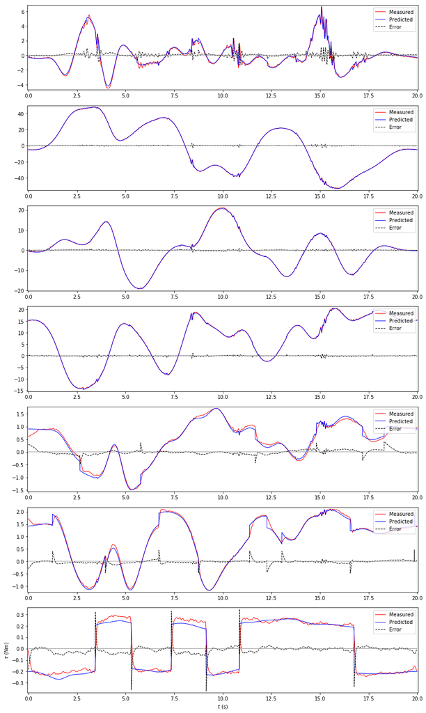

```python
from support_funcs.regr_data_proc import  plot_meas_pred_tau

import matplotlib.pyplot as plt
plt.rcParams['figure.figsize'] = [12,20]

proc = numpy.load(tmpfolder + 'procdata/' + indentification_traj + '_proc.npz')
t = proc['t']
tau = proc['tau']

tau_p = np.zeros(tau.shape)
tau_ps = W.dot(beta_ols_fbpe)
for i in range(dof):
    tau_p[:, i] = tau_ps[i::dof].flatten()

trajectory_sampling_rate = real_robot_trajectory_sampling_rate
plot_data_num = int(1 / base_freq * trajectory_sampling_rate)
save_fig_path = tmpfolder + 'solutions/fig/'+robot_name+'_fbpe-ols_result.png'
plot_meas_pred_tau(save_fig_path, t[:plot_data_num], tau[:plot_data_num, :],
                   tau_p[:plot_data_num, :])
```

### Solution Double Check

```python
dict_subs = dict(zip(beta_symbs, beta_ols_fbpe.flatten().tolist()[0]))
dict_subs.update(dict(zip(delta_d, delta_d_ols_fbpe.flatten().tolist()[0])))

test = 'ok'
for i, DBi in enumerate(EB_blocks):
        m = numpy.matrix(mrepl(DBi, dict_subs)).astype(float)
        for v in numpy.linalg.eigvals( m ):
            if v <= 0.0:
                print i, v
                test = 'fail'
print(test)
```

```
ok
```

```python
numpy.savetxt(tmpfolder + 'solutions/'+robot_name+'_' + indentification_traj + '_beta_ols_fbpe.dat', beta_ols_fbpe)
numpy.savetxt(tmpfolder + 'solutions/'+robot_name+'_' + indentification_traj + '_delta_ols_fbpe.dat', delta_ols_fbpe)
```

## Method 4:Feasible Base Parameter Estimation with Weight Least Squares (FBPE-WLS)

```python
u = sympy.Symbol('u')
U_rho = BlockMatrix([[Matrix([u - rho2_norm_sqr_wls]), (rho1_wls - R1_wls*beta_symbs).T],
                     [rho1_wls - R1_wls*beta_symbs,                       I(n_beta)]])
U_rho = U_rho.as_explicit()
```

```python
lmis_fbpe_wls = [LMI(U_rho)] + EB_LMIs_marg
```

```python
variables_fbpe_wls = [u] + list(beta_symbs) + list(delta_d)
```

```python
objf_fbpe_wls = u
```

```python
sol_fbpe_wls = solve_sdp(objf_fbpe_wls, lmis_fbpe_wls, variables_fbpe_wls)
```

```
sdp.dat-s -save dsdp5.out -gaptol 1e-07

Variables 85
Matrix Blocks: 22, Total Number of Constraints: 114
Nonzeros in Constraints: 1965

Read Data File into Buffer:      2.421e-03 seconds
DSDP Set Data:                   7.701e-05 seconds
DSDP Process Data:               9.823e-03 seconds

Data Norms: C: 3.48e+02, A: 3.93e+03, b: 1.00e+00
Scale C: 1.00e+00

Potential Parameter: 5.00
Reapply Schur matrix: 4

Iter   PP Objective      DD Objective    PInfeas   DInfeas     Nu     StepLength   Pnrm
---------------------------------------------------------------------------------------
0     1.00000000e+10   -9.17774658e+15   2.0e+00   9.2e+07   9.2e+15  0.00  0.00   0.00
10    2.57865980e+11   -7.04437173e+10   1.3e+03   7.0e+02   7.4e+08  1.00  1.00   1.15
20    7.88364053e+08   -1.12434440e+08   6.3e+00   1.0e+00   2.3e+06  1.00  1.00   0.85
30    5.31066445e+06   -3.69336816e+05   7.9e-03   0.0e+00   1.4e+04  1.00  1.00   0.57
40    6.19343543e+04   -3.94458445e+03   9.2e-05   0.0e+00   1.8e+02  1.00  1.00   0.45
50    2.41128573e+02   -2.76801060e+02   7.2e-07   0.0e+00   9.5e-01  1.00  1.00   1.19
60   -2.63635830e+02   -2.64184911e+02   7.7e-10   0.0e+00   2.1e-04  1.00  1.00   5.07
67   -2.64182051e+02   -2.64182064e+02   7.7e-07   0.0e+00   8.9e-09  1.00  0.16  15.52
DSDP Converged.

P Objective  :  -2.64182060e+02
DSDP Solution:  -2.64182064e+02

DSDP Solve Time:                     1.274e-01 seconds
DSDP Preparation and Solve Time:     1.372e-01 seconds


P Infeasible: 2.24e-10
D Infeasible: 0.00e+00
Minimal P Eigenvalue: 0.00e+00
Minimal D Eigenvalue: 0.00
Relative P - D Objective values: 7.82e-09
```

[output cut: 20 more lines]

```
                                Cone View          68   1.2207e-04   0.09
                           Cone Compute X           1   7.9298e-04   0.58
                            SDP VecMatVec       11344   1.7659e-02  12.86
                                  SDP Dot       12078   5.2848e-03   3.85
                               SDP SSolve       29739   1.3955e-02  10.16
                                SDP X+vv'       18395   6.1357e-03   4.47
                        Factor Newton Eq.          68   5.2569e-03   3.83
                         Solve Newton Eq.         593   3.7968e-03   2.77
                              Primal Step          67   5.1279e-03   3.74
                                Dual Step          67   5.1923e-03   3.78
                           Corrector Step         248   4.0955e-02  29.83
                                 CG Solve         384   6.1643e-03   4.49
                               DSDP Solve           1   1.2656e-01  92.19
--------------------------------------------------------------------------
--- DSDP Finished ---
```

```python
u_wls_fbpe = sol_fbpe_wls[0,0]
beta_wls_fbpe = numpy.matrix(sol_fbpe_wls[1:1+n_beta])
delta_d_wls_fbpe = numpy.matrix(sol_fbpe_wls[1+n_beta:])
delta_wls_fbpe = Pb*beta_wls_fbpe + (-Pb*rbt.dyn.Kd+rbt.dyn.Pd)*delta_d_wls_fbpe
```

```python
u_wls_fbpe
```

```
264.1820640725936
```

### plot measured and predicted torque

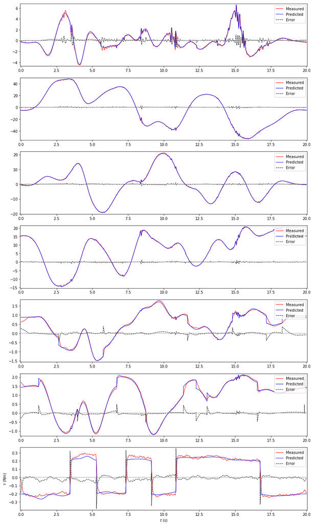

```python
from support_funcs.regr_data_proc import  plot_meas_pred_tau

import matplotlib.pyplot as plt
plt.rcParams['figure.figsize'] = [12,20]

proc = numpy.load(tmpfolder + 'procdata/' + indentification_traj + '_proc.npz')
t = proc['t']
tau = proc['tau']

tau_p = np.zeros(tau.shape)
tau_ps = W.dot(beta_wls_fbpe)
for i in range(dof):
    tau_p[:, i] = tau_ps[i::dof].flatten()

trajectory_sampling_rate = real_robot_trajectory_sampling_rate
plot_data_num = int(1 / base_freq * trajectory_sampling_rate)
save_fig_path = tmpfolder + 'solutions/fig/'+robot_name+'_fbpe-wls_result.png'
plot_meas_pred_tau(save_fig_path, t[:plot_data_num], tau[:plot_data_num, :],
                   tau_p[:plot_data_num, :])
```

### Solution Double Check

```python
dict_subs = dict(zip(beta_symbs, beta_wls_fbpe.flatten().tolist()[0]))
dict_subs.update(dict(zip(delta_d, delta_d_wls_fbpe.flatten().tolist()[0])))

test = 'ok'
for EBi in EB_blocks:
        m = numpy.matrix(mrepl(EBi, dict_subs)).astype(float)
        for v in numpy.linalg.eigvals( m ):
            if v <= 0.0:
                print(v)
                test = 'fail'
print(test)
```

```
ok
```

```python
numpy.savetxt(tmpfolder + 'solutions/'+robot_name+'_' + indentification_traj + '_beta_wls_fbpe.dat', beta_wls_fbpe)
numpy.savetxt(tmpfolder + 'solutions/'+robot_name+'_' + indentification_traj + '_delta_wls_fbpe.dat', delta_wls_fbpe)
```

## Method 5:Additional Constraints on Centers-of-Mass

```python
# import sympy as sp
# link_cuboid_hulls = [
# [[ +0.000005 , +0.000006 ],[ -0.04 , -0.03 ],[ -0.07 , -0.06 ]],
# [[ -0.000005 , -0.000004 ],[ 0.09 , 0.10 ],[ +0.03 , +0.04 ]],
# [[ +0.0000009 , +0.000001 ],[ -0.03 , -0.02 ],[ -0.06 , -0.05 ]],
# [[ -0.000004 , -0.000003 ],[ +0.07 , +0.08 ],[ +0.03 , +0.04 ]],
# [[ +0.000009 , +0.000010 ],[ -0.03 , -0.02 ],[ -0.07 , -0.06 ]],
# [[ -0.000011 , -0.00010 ],[ +0.09 , +0.10 ],[ +0.01 , +0.02 ]],
# [[ +0.00003 , +0.00004 ],[ +0.02 , +0.03 ],[ -0.05 , -0.04 ]],
# ]


# link_cuboid_hulls = [
# [[ -0.140 , +0.140 ],[ -0.174 , +0.174 ],[ -0.084 , +0.346 ]],
# [[ -0.084 , +0.084 ],[ -0.174 , +0.174 ],[ -0.084 , +0.170 ]],
# [[ -0.090 , +0.040 ],[ -0.550 , +0.040 ],[ -0.045 , +0.045 ]],
# [[ -0.045 , +0.095 ],[ -0.045 , +0.045 ],[ -0.050 , +0.830 ]],
# [[ -0.045 , +0.045 ],[ -0.020 , +0.100 ],[ -0.045 , +0.045 ]],
# [[ -0.045 , +0.045 ],[ -0.060 , +0.045 ],[ -0.020 , +0.060 ]],
# [[ -0.045 , +0.045 ],[ -0.045 , +0.045 ],[ -0.018 , +0.001 ]],
# ]


# robotmaxmass = 22   # xmate
robotmaxmass = 20   # franka
```

#### LMI Matrix Definition

```python
D_add_blocks = []
# for i in range(rbt.dof):
#     l = rbt.rbtdef.l[i]
#     m = rbt.rbtdef.m[i]
#     link_cuboid_hull = link_cuboid_hulls[i]
#     for j in range(3):
#         D_add_blocks.append( Matrix( [[  l[j] - m*link_cuboid_hull[j][0] ]] ) )
#         D_add_blocks.append( Matrix( [[ -l[j] + m*link_cuboid_hull[j][1] ]] ) )

# # xmate
# D_add_blocks.append( Matrix( [[ rbt.rbtdef.m[0] - 5.4 ]] ) )
# D_add_blocks.append( Matrix( [[ -rbt.rbtdef.m[0] + 5.5 ]] ) )
# D_add_blocks.append( Matrix( [[ rbt.rbtdef.m[1] - 4.6 ]] ) )
# D_add_blocks.append( Matrix( [[ -rbt.rbtdef.m[1] + 4.7 ]] ) )
# D_add_blocks.append( Matrix( [[ rbt.rbtdef.m[2] - 2.6 ]] ) )
# D_add_blocks.append( Matrix( [[ -rbt.rbtdef.m[2] + 2.7 ]] ) )
# D_add_blocks.append( Matrix( [[ rbt.rbtdef.m[3] - 2.6 ]] ) )
# D_add_blocks.append( Matrix( [[ -rbt.rbtdef.m[3] + 2.7 ]] ) )
# D_add_blocks.append( Matrix( [[ rbt.rbtdef.m[4] - 2.5 ]] ) )
# D_add_blocks.append( Matrix( [[ -rbt.rbtdef.m[4] + 2.6 ]] ) )
# D_add_blocks.append( Matrix( [[ rbt.rbtdef.m[5] - 1.9 ]] ) )
# D_add_blocks.append( Matrix( [[ -rbt.rbtdef.m[5] + 2.0 ]] ) )
# D_add_blocks.append( Matrix( [[ rbt.rbtdef.m[6] - 0.8 ]] ) )
# D_add_blocks.append( Matrix( [[ -rbt.rbtdef.m[6] + 0.9 ]] ) )

# franka
D_add_blocks.append( Matrix( [[ rbt.rbtdef.m[0] ]] ) )
D_add_blocks.append( Matrix( [[ -rbt.rbtdef.m[0] + 10 ]] ) )
D_add_blocks.append( Matrix( [[ rbt.rbtdef.m[1] ]] ) )
D_add_blocks.append( Matrix( [[ -rbt.rbtdef.m[1] + 10 ]] ) )
D_add_blocks.append( Matrix( [[ rbt.rbtdef.m[2] ]] ) )
D_add_blocks.append( Matrix( [[ -rbt.rbtdef.m[2] + 10 ]] ) )
D_add_blocks.append( Matrix( [[ rbt.rbtdef.m[3] ]] ) )
D_add_blocks.append( Matrix( [[ -rbt.rbtdef.m[3] + 10 ]] ) )
D_add_blocks.append( Matrix( [[ rbt.rbtdef.m[4] ]] ) )
D_add_blocks.append( Matrix( [[ -rbt.rbtdef.m[4] + 10 ]] ) )
D_add_blocks.append( Matrix( [[ rbt.rbtdef.m[5] ]] ) )
D_add_blocks.append( Matrix( [[ -rbt.rbtdef.m[5] + 10 ]] ) )
D_add_blocks.append( Matrix( [[ rbt.rbtdef.m[6] ]] ) )
D_add_blocks.append( Matrix( [[ -rbt.rbtdef.m[6] + 10 ]] ) )

D_add_blocks.append(Matrix([robotmaxmass - sum(rbt.rbtdef.m)]))
```

#### Variable Change and LMI Definition

```python
DB_add_blocks = [ mrepl(Di, varchange_dict) for Di in D_add_blocks ]
```

```python
DB_add_LMIs = list(map(LMI_PD, DB_add_blocks))
```

```python
DB_add_LMIs_marg = list(map(lambda lm: LMI(lm, epsilon_safemargin*eye(lm.shape[0])) , DB_add_blocks))
```

```python
DB_add_LMIs_marg[0]
```

```
Matrix([[m_1]]) >= Matrix([[1.0e-30]])
```

```python
DB_add_LMIs_marg[-1]
```

```
Matrix([[-m_1 - m_2 - m_3 - m_4 - m_5 - m_6 - m_7 + 20]]) >= Matrix([[1.0e-30]])
```

### Testing $\beta^\star$ solution on new constraints

```python
dict_subs = dict(zip(beta_symbs, beta_wls_fbpe.flatten().tolist()[0]))
lmis_star_bpft_add = [ lmi_sdp.LMI_PD(mrepl(lmi.canonical().gts, dict_subs)) for lmi in DB_add_LMIs_marg ]
variables_star_bpft_add = list(delta_d)
objf_star_bpft_add = delta_d[0]
```

```python
sol_star_bpft_add = solve_sdp(objf_star_bpft_add, lmis_star_bpft_add, variables_star_bpft_add)
```

```
sdp.dat-s -save dsdp5.out -gaptol 1e-07

Variables 27
Matrix Blocks: 15, Total Number of Constraints: 15
Nonzeros in Constraints: 36

Read Data File into Buffer:      6.700e-05 seconds
DSDP Set Data:                   3.505e-05 seconds
Trying Sparse M: Total nonzeros: 21 of 351
DSDP Process Data:               7.105e-05 seconds

Data Norms: C: 3.32e+01, A: 4.58e+00, b: 1.00e+00
Scale C: 1.41e-01

Potential Parameter: 5.00
Reapply Schur matrix: 10

Iter   PP Objective      DD Objective    PInfeas   DInfeas     Nu     StepLength   Pnrm
---------------------------------------------------------------------------------------
0     1.00000000e+10   -1.42802827e+10   2.0e+00   1.4e+02   1.4e+10  0.00  0.00   0.00
7     1.00000005e+07    1.00000000e+07   1.0e+00   0.0e+00   1.3e-03  1.00  0.23   4.04
DSDP Converged.
DSDP Dual Unbounded, Primal Infeasible

P Objective  :   1.00198916e-01
DSDP Solution:   1.00000000e+07

DSDP Solve Time:                     2.794e-03 seconds
DSDP Preparation and Solve Time:     2.865e-03 seconds


P Infeasible: 5.00e-01
D Infeasible: 0.00e+00
Minimal P Eigenvalue: 0.00e+00
Minimal D Eigenvalue: 0.00
Relative P - D Objective values: -1.00e-00
Relative X Dot S: 1.00e-08

Max Y: 1.00000000e+07,  Bounded by 1.0e+07
Trace X: 2.78271646e-02,   Bounded by Penalty Parameter: 1.0e+08
```

[output cut: 15 more lines]

```
                           Cone Potential          80   2.7299e-04   9.36
                                Cone View           8   1.7643e-05   0.61
                           Cone Compute X           1   5.2929e-05   1.82
                                  SDP Dot        1113   3.8743e-04  13.29
                               SDP SSolve         204   4.3154e-05   1.48
                                SDP X+vv'         204   6.9141e-05   2.37
                        Factor Newton Eq.           8   8.1062e-06   0.28
                         Solve Newton Eq.         103   7.3910e-05   2.53
                              Primal Step           7   9.8228e-05   3.37
                                Dual Step           7   9.8944e-05   3.39
                           Corrector Step          60   1.9829e-03  68.00
                                 CG Solve          75   1.6832e-04   5.77
                               DSDP Solve           1   2.7370e-03  93.86
--------------------------------------------------------------------------
--- DSDP Finished ---
```

### Finding new solution

```python
lmis_fbpe_ols_add = [LMI(U_rho)] + EB_LMIs_marg + DB_add_LMIs_marg
```

```python
variables_fbpe_ols_add = [u] + list(beta_symbs) + list(delta_d)
```

```python
objf_fbpe_ols_add = u
```

```python
sol_fbpe_ols_add = solve_sdp(objf_fbpe_ols_add, lmis_fbpe_ols_add, variables_fbpe_ols_add)
```

```
sdp.dat-s -save dsdp5.out -gaptol 1e-07

Variables 85
Matrix Blocks: 37, Total Number of Constraints: 129
Nonzeros in Constraints: 2001

Read Data File into Buffer:      2.344e-03 seconds
DSDP Set Data:                   8.702e-05 seconds
DSDP Process Data:               9.585e-03 seconds

Data Norms: C: 3.50e+02, A: 3.93e+03, b: 1.00e+00
Scale C: 1.00e+00

Potential Parameter: 5.00
Reapply Schur matrix: 4

Iter   PP Objective      DD Objective    PInfeas   DInfeas     Nu     StepLength   Pnrm
---------------------------------------------------------------------------------------
0     1.00000000e+10   -9.57565480e+15   2.0e+00   9.6e+07   9.6e+15  0.00  0.00   0.00
10    1.18954152e+11   -3.00691688e+10   5.4e+02   3.0e+02   2.5e+08  1.00  1.00   1.82
20    2.92530206e+08   -6.37230905e+06   9.1e-01   0.0e+00   3.7e+05  1.00  1.00   0.31
30    1.73902272e+06   -6.74735056e+04   1.1e-03   0.0e+00   3.4e+03  1.00  1.00   0.69
40    7.79272271e+03   -5.49528213e+02   4.9e-06   0.0e+00   1.6e+01  1.00  1.00   1.10
50   -2.52103460e+02   -2.64392692e+02   7.3e-09   0.0e+00   1.2e-02  1.00  1.00   4.44
59   -2.64190089e+02   -2.64190102e+02   7.7e-15   0.0e+00   8.5e-09  1.00  1.00   1.45
DSDP Converged.

P Objective  :  -2.64190097e+02
DSDP Solution:  -2.64190102e+02

DSDP Solve Time:                     1.195e-01 seconds
DSDP Preparation and Solve Time:     1.291e-01 seconds


P Infeasible: 2.07e-10
D Infeasible: 0.00e+00
Minimal P Eigenvalue: 0.00e+00
Minimal D Eigenvalue: 0.00
Relative P - D Objective values: 9.45e-09
Relative X Dot S: 3.16e-08
```

[output cut: 19 more lines]

```
                                Cone View          60   1.1563e-04   0.09
                           Cone Compute X           1   8.5711e-04   0.66
                            SDP VecMatVec        9747   1.5255e-02  11.81
                                  SDP Dot       15580   6.3379e-03   4.91
                               SDP SSolve       27291   1.2545e-02   9.71
                                SDP X+vv'       17544   5.8732e-03   4.55
                        Factor Newton Eq.          59   4.5741e-03   3.54
                         Solve Newton Eq.         521   3.2821e-03   2.54
                              Primal Step          59   4.9770e-03   3.85
                                Dual Step          59   4.9119e-03   3.80
                           Corrector Step         224   4.0835e-02  31.61
                                 CG Solve         344   5.3849e-03   4.17
                               DSDP Solve           1   1.1862e-01  91.82
--------------------------------------------------------------------------
--- DSDP Finished ---
```

```python
u_starextra = sol_fbpe_ols_add[0,0]
beta_starextra = numpy.matrix(sol_fbpe_ols_add[1:1+n_beta])
delta_d_starextra = numpy.matrix(sol_fbpe_ols_add[1+n_beta:])
delta_starextra = Pb*beta_starextra + (-Pb*rbt.dyn.Kd+rbt.dyn.Pd)*delta_d_starextra
```

```python
u_starextra
```

```
264.1901017065233
```

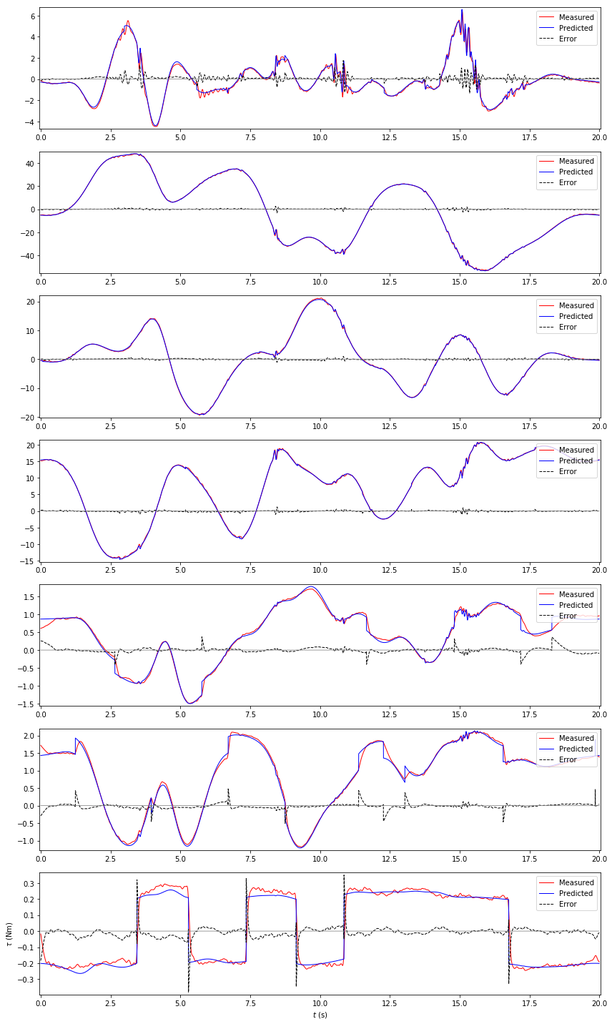

```python
from support_funcs.regr_data_proc import  plot_meas_pred_tau

import matplotlib.pyplot as plt
plt.rcParams['figure.figsize'] = [12,20]

proc = numpy.load(tmpfolder + 'procdata/' + indentification_traj + '_proc.npz')
t = proc['t']
tau = proc['tau']

tau_p = np.zeros(tau.shape)
tau_ps = W.dot(beta_starextra)
for i in range(dof):
    tau_p[:, i] = tau_ps[i::dof].flatten()

trajectory_sampling_rate = real_robot_trajectory_sampling_rate
plot_data_num = int(1 / base_freq * trajectory_sampling_rate)
save_fig_path = tmpfolder + 'solutions/fig/'+robot_name+'_starextra_result.png'
plot_meas_pred_tau(save_fig_path, t[:plot_data_num], tau[:plot_data_num, :],
                   tau_p[:plot_data_num, :])
```

### Solution Double Check

```python
dict_subs = dict(zip(beta_symbs, beta_starextra.flatten().tolist()[0]))
dict_subs.update(dict(zip(delta_d, delta_d_starextra.flatten().tolist()[0])))

test = 'ok'
for DBi in (EB_blocks + DB_add_blocks):
        m = numpy.matrix(mrepl(DBi, dict_subs)).astype(float)
        for v in numpy.linalg.eigvals( m ):
            if v <= 0.0: test = 'fail'
print(test)
```

```
ok
```

```python
numpy.savetxt(tmpfolder + 'solutions/'+robot_name+'_' + indentification_traj + '_beta_starextra.dat', beta_starextra)
numpy.savetxt(tmpfolder + 'solutions/'+robot_name+'_' + indentification_traj + '_delta_starextra.dat', delta_starextra)
```

### Inertia Matrix Definiteness Tests

```python
def test_mass_matrix_psd(beta_solution):
    K = rbt.dyn.Pb.T + rbt.dyn.Kd * rbt.dyn.Pd.T
    A = numpy.matrix(K).astype(float)
    b = numpy.matrix(beta_solution).astype(float)
    x = numpy.linalg.pinv(A) * b
    d_test = x

    M_func_def = sympybotics.robotcodegen.robot_code_to_func( 'python', rbt.M_code, 'M', 'M_func', rbt.rbtdef)
    exec(M_func_def, globals())
    global sin, cos
    from math import sin, cos

    ntests = 10000

    ok = 0
    nok = 0
    for i in range(ntests):
        q_test = numpy.random.rand(rbt.dof)
        M_out = M_func( numpy.array(d_test).flatten().tolist(), q_test)
        M = numpy.matrix(M_out).reshape((rbt.dof,rbt.dof))
        try:
            c = numpy.linalg.cholesky(M)
        except:
            nok += 1
            continue
        ok += 1

    print 'ok     %8i  %3i%%'%(ok, 100.0*ok/ntests)
    print 'not ok %8i  %3i%%'%(nok, 100.0*nok/ntests)
    if nok > 0 :
        print('\nNot PSD -> Not feasible!')
    else:
        print('\nSeems feasible.')
```

```python
beta_ols = numpy.matrix(numpy.loadtxt(tmpfolder + 'solutions/'+robot_name+'_traj1_beta_ols.dat')).T
test_mass_matrix_psd(beta_ols)
```

```
ok            0    0%
not ok    10000  100%

Not PSD -> Not feasible!
```

```python
beta_wls = numpy.matrix(numpy.loadtxt(tmpfolder + 'solutions/'+robot_name+'_traj1_beta_wls.dat')).T
test_mass_matrix_psd(beta_wls)
```

```
ok            0    0%
not ok    10000  100%

Not PSD -> Not feasible!
```

```python
beta_ols_fbpe = numpy.matrix(numpy.loadtxt(tmpfolder + 'solutions/'+robot_name+'_traj1_beta_ols_fbpe.dat')).T
test_mass_matrix_psd(beta_ols_fbpe)
```

```
ok        10000  100%
not ok        0    0%

Seems feasible.
```

```python
beta_wls_fbpe = numpy.matrix(numpy.loadtxt(tmpfolder + 'solutions/'+robot_name+'_traj1_beta_wls_fbpe.dat')).T
test_mass_matrix_psd(beta_wls_fbpe)
```

```
ok        10000  100%
not ok        0    0%

Seems feasible.
```

```python
beta_starextra = numpy.matrix(numpy.loadtxt(tmpfolder + 'solutions/'+robot_name+'_traj1_beta_starextra.dat')).T
test_mass_matrix_psd(beta_starextra)
```

```
ok        10000  100%
not ok        0    0%

Seems feasible.
```

```python
from support_funcs.utils import ListTable

form = '%.4g'

import sympy

table = ListTable()
header = ['', 'beta_cad', 'beta_ols', 'beta_wls', 'beta_ols_fbpe','beta_wls_fbpe','beta_starextra']
table.append(header)
for i, b in enumerate(rbt.dyn.baseparms.n()):
    cad_v = '---'
    row = ['%.7s ...'%b if len(str(b)) > 107 else str(b), cad_v]
#     row += [form%solutions_beta['beta_ols'][i,0], '%.2g'%analysis['id']['betas']['beta_ols']['sd%'][i,0]]
    row += [form%beta_ols[i,0]]
    row += [form%beta_wls[i,0]]
    row += [form%beta_ols_fbpe[i,0]]
    row += [form%beta_wls_fbpe[i,0]]
    row += [form%beta_starextra[i,0]]
    table.append(row)
table
```

|  | beta_cad | beta_ols | beta_wls | beta_ols_fbpe | beta_wls_fbpe | beta_starextra |
| --- | --- | --- | --- | --- | --- | --- |
| L_1zz + L_2yy | --- | -0.02971 | -0.02752 | 0.006135 | 0.003063 | 0.003441 |
| fv_1 | --- | 0.02047 | 0.03129 | 0.02047 | 0.03949 | 0.03823 |
| fc_1 | --- | 0.2357 | 0.2331 | 0.2357 | 0.2294 | 0.2296 |
| L_2xx - ... | --- | 1.048 | 1.027 | 1.048 | 0.9693 | 0.9684 |
| L_2xy | --- | -0.007841 | -0.01031 | -0.008979 | 0.001969 | 0.003555 |
| L_2xz | --- | -0.06211 | 0.01148 | -0.0619 | 0.01461 | 0.0151 |
| L_2yz | --- | 0.04769 | 0.03973 | 0.03474 | 0.02274 | 0.02496 |
| L_2zz + ... | --- | 1.112 | 1.086 | 1.113 | 1.14 | 1.14 |
| l_2x | --- | 0.0197 | 0.02225 | 0.0197 | 0.02364 | 0.02352 |
| l_2y - l_3z - 0.316*m_3 - 0.316*m_4 - 0.316*m_5 - 0.316*m_6 - 0.316*m_7 | --- | -3.127 | -3.127 | -3.127 | -3.128 | -3.128 |
| fv_2 | --- | 0.1418 | 0.1842 | 0.1418 | 0.169 | 0.1727 |
| fc_2 | --- | 0.1707 | 0.1383 | 0.1707 | 0.1498 | 0.1482 |
| L_3xx - L_3yy + L_4yy - 0.00680625*m_4 | --- | -0.02509 | 0.006771 | -0.02411 | 0.01538 | 0.0147 |
| L_3xy + 0.0825*l_4z | --- | 0.02001 | 0.01737 | 0.01913 | 0.002481 | 0.002811 |
| L_3xz | --- | -0.0088 | -0.01985 | 0.00167 | -0.02727 | -0.02399 |
| L_3yz | --- | 0.008092 | 0.03834 | 0.00337 | 0.01641 | 0.01503 |
| L_3zz + L_4yy + 0.00680625*m_4 + 0.0136125*m_5 + 0.0136125*m_6 + 0.0136125*m_7 | --- | 0.06836 | 0.0677 | 0.09633 | 0.1052 | 0.1052 |
| l_3x + 0.0825*m_4 + 0.0825*m_5 + 0.0825*m_6 + 0.0825*m_7 | --- | 0.688 | 0.6849 | 0.6847 | 0.6813 | 0.6816 |
| l_3y - l_4z | --- | 0.01137 | 0.02149 | 0.01286 | 0.02078 | 0.02064 |
| fv_3 | --- | 0.08952 | 0.08559 | 0.08952 | 0.1081 | 0.1082 |
| fc_3 | --- | 0.1718 | 0.1726 | 0.1718 | 0.1654 | 0.1659 |
| L_4xx - L_4yy + L_5yy + 0.768*l_5z + 0.14064975*m_5 + 0.14064975*m_6 + 0.14064975*m_7 | --- | 0.5822 | 0.5698 | 0.5832 | 0.552 | 0.552 |
| L_4xy + 0.0825*l_5z + 0.03168*m_5 + 0.03168*m_6 + 0.03168*m_7 | --- | 0.1578 | 0.1294 | 0.1471 | 0.1287 | 0.1293 |
| L_4xz | --- | 0.02383 | -0.005939 | 0.02566 | -0.000981 | -0.0006063 |
| L_4yz | --- | 0.03487 | 0.02597 | 0.02529 | 0.005558 | 0.005495 |
| L_4zz + L_5yy + 0.768*l_5z + 0.15426225*m_5 + 0.15426225*m_6 + 0.15426225*m_7 | --- | 0.6381 | 0.6557 | 0.6389 | 0.6538 | 0.654 |
| l_4x - 0.0825*m_5 - 0.0825*m_6 - 0.0825*m_7 | --- | -0.4875 | -0.4896 | -0.4861 | -0.4889 | -0.4888 |
| l_4y + l_5z + 0.384*m_5 + 0.384*m_6 + 0.384*m_7 | --- | 1.76 | 1.768 | 1.76 | 1.768 | 1.768 |
| fv_4 | --- | -0.03055 | 0.03304 | 4.71e-09 | 1.995e-06 | 4.662e-07 |
| fc_4 | --- | 0.3232 | 0.2907 | 0.3232 | 0.2912 | 0.291 |
| L_5xx - L_5yy + L_6yy + 0.007744*m_7 | --- | -0.007627 | -0.01608 | -0.005827 | -0.01283 | -0.01272 |
| L_5xy | --- | -0.004925 | -0.03113 | -0.004396 | -0.02975 | -0.02972 |
| L_5xz | --- | -0.008765 | 0.007225 | -0.007886 | 0.00373 | 0.0037 |
| L_5yz | --- | 0.0005203 | -0.009627 | 0.0006491 | -0.01461 | -0.01457 |
| L_5zz + L_6yy + 0.007744*m_7 | --- | 0.04938 | 0.04653 | 0.04948 | 0.04713 | 0.04709 |
| l_5x | --- | -0.008169 | -0.001512 | -0.00827 | -0.001005 | -0.001013 |
| l_5y - l_6z | --- | 0.08685 | 0.07983 | 0.0867 | 0.07996 | 0.07996 |
| fv_5 | --- | 0.1076 | 0.06225 | 0.1076 | 0.06543 | 0.06539 |
| fc_5 | --- | 0.1735 | 0.1852 | 0.1735 | 0.185 | 0.185 |
| L_6xx - L_6yy + L_7yy - 0.007744*m_7 | --- | 0.002927 | 0.0007112 | 0.003404 | 0.003808 | 0.003789 |
| L_6xy + 0.088*l_7z | --- | 0.01561 | 0.0008094 | 0.01425 | 0.0003729 | 0.0003362 |
| L_6xz | --- | 0.01046 | 0.01947 | 0.00949 | 0.01642 | 0.01644 |
| L_6yz | --- | 0.001037 | -0.01388 | -0.0008216 | -0.009144 | -0.009114 |
| L_6zz + L_7yy + 0.007744*m_7 | --- | 0.01277 | 0.00932 | 0.01893 | 0.02282 | 0.02284 |
| l_6x + 0.088*m_7 | --- | 0.1674 | 0.1673 | 0.1663 | 0.1668 | 0.1668 |
| l_6y - l_7z | --- | -0.05997 | -0.06242 | -0.05962 | -0.06249 | -0.0625 |
| fv_6 | --- | 0.05878 | 0.07295 | 0.05878 | 0.07637 | 0.07637 |
| fc_6 | --- | 0.2344 | 0.2336 | 0.2344 | 0.235 | 0.235 |
| L_7xx - L_7yy | --- | -0.002778 | 0.003261 | -5.806e-05 | 0.002001 | 0.001997 |
| L_7xy | --- | 0.009632 | 0.009373 | 0.003775 | 0.009714 | 0.009716 |
| L_7xz | --- | -0.001305 | 0.0002337 | 0.0007516 | -0.001778 | -0.00178 |
| L_7yz | --- | 0.0101 | -0.004522 | 0.0007808 | -0.00175 | -0.00175 |
| L_7zz | --- | -0.0165 | -0.001215 | 0.0002228 | 0.0004504 | 0.0004494 |
| l_7x | --- | 0.002866 | 0.002604 | 0.002372 | 0.002493 | 0.002493 |
| l_7y | --- | 0.002263 | 0.0008819 | 0.00158 | 0.0009236 | 0.0009238 |
| fv_7 | --- | 0.04327 | 0.04052 | 0.04327 | 0.04105 | 0.04105 |
| fc_7 | --- | 0.1995 | 0.2006 | 0.1995 | 0.2007 | 0.2007 |

```python
delta_ols_fpe = numpy.matrix(numpy.loadtxt(tmpfolder + 'solutions/'+robot_name+'_traj1_delta_ols_fbpe.dat')).T
delta_wls_fpe = numpy.matrix(numpy.loadtxt(tmpfolder + 'solutions/'+robot_name+'_traj1_delta_wls_fbpe.dat')).T
delta_starextra = numpy.matrix(numpy.loadtxt(tmpfolder + 'solutions/'+robot_name+'_traj1_delta_starextra.dat')).T
form = '%.6g'

table = ListTable()
header = ['', 'Dcad', 'delta_ols_fpe', 'delta_wls_fpe', 'delta_starextra']
table.append(header)
for i, d in enumerate(rbt.dyn.dynparms):
    cad_v = '---'
    row = ['%.7s ...'%b if len(str(d)) > 7 else str(d), cad_v]
    row += [form%delta_ols_fpe[i,0]]
    row += [form%delta_wls_fpe[i,0]]
    row += [form%delta_starextra[i,0]]
    table.append(row)
table
```

|  | Dcad | delta_ols_fpe | delta_wls_fpe | delta_starextra |
| --- | --- | --- | --- | --- |
| L_1xx | --- | 5.7735e+06 | 5.7735e+06 | 5.7735e+06 |
| L_1xy | --- | -1.36838e-11 | -3.35312e-11 | -3.31833e-11 |
| L_1xz | --- | 9.13989e-12 | -5.00571e-08 | -6.60347e-10 |
| L_1yy | --- | 5.7735e+06 | 5.7735e+06 | 5.7735e+06 |
| L_1yz | --- | 9.13989e-12 | -5.0057e-08 | -6.60347e-10 |
| L_1zz | --- | 4.04957e-09 | 9.2903e-09 | 2.0373e-09 |
| l_1x | --- | 2.14143e-10 | 5.07886e-08 | -2.08092e-20 |
| l_1y | --- | -2.14143e-10 | -5.07885e-08 | 2.08092e-20 |
| l_1z | --- | -1.11543e-11 | -1.76169e-11 | -3.90893e-12 |
| m_1 | --- | 7.74597e+06 | 7.74597e+06 | 4.9664e-05 |
| fv_1 | --- | 0.0204746 | 0.0394912 | 0.0382319 |
| fc_1 | --- | 0.235719 | 0.229419 | 0.229587 |
| L_2xx | --- | 0.139111 | 0.00126909 | 0.0198491 |
| L_2xy | --- | -0.00897862 | 0.00196876 | 0.00355472 |
| L_2xz | --- | -0.0619042 | 0.0146143 | 0.0150958 |
| L_2yy | --- | 0.0061353 | 0.00306296 | 0.00344097 |
| L_2yz | --- | 0.0347389 | 0.0227427 | 0.0249556 |
| L_2zz | --- | 0.197668 | 0.168871 | 0.188279 |
| l_2x | --- | 0.0196975 | 0.0236419 | 0.0235248 |
| l_2y | --- | -0.482287 | -0.486216 | -0.286718 |
| l_2z | --- | 0.0871909 | 0.0583276 | 0.0322464 |
| m_2 | --- | 7.74597e+06 | 7.74597e+06 | 4.50525 |
| fv_2 | --- | 0.141785 | 0.169008 | 0.17268 |
| fc_2 | --- | 0.170735 | 0.149766 | 0.148177 |
| L_3xx | --- | 766198 | 766198 | 0.675793 |
| L_3xy | --- | 0.0202437 | -8.51627e-05 | 0.000539717 |
| L_3xz | --- | 0.00167033 | -0.027272 | -0.023993 |
| L_3yy | --- | 766198 | 766198 | 0.642618 |
| L_3yz | --- | 0.0033699 | 0.0164086 | 0.0150264 |
| L_3zz | --- | 0.00261569 | 0.000777091 | 0.00228308 |

[output cut: 54 more lines]

# 5 - Regression Model Validation

```python
import numpy as np
import sympybotics
import pickle

from collections import OrderedDict
from support_funcs.utils import ListTable
```

```python
with open(tmpfolder +  'robotmodels/'+robot_name+'.pkl', 'rb' ) as file:
          rbt = pickle.load( file )
```

```python
def analyse(W, omega, R1, beta):
    from numpy import matrix, mean
    from numpy.linalg import cond, norm

    p = dict()

    n = W.shape[0]

    omega_norm = norm(omega)
    omega_mean = mean(omega)

    p['err'] = norm(omega - W * beta)
    p['merr'] = p['err'] / n

    p['se'] = p['err']**2
    p['mse'] = p['se']/(n-W.shape[1])
    p['rmse'] = p['mse']**0.5

    C = p['mse'] * (R1.T * R1).I
    p['sd'] = np.sqrt(C.diagonal()).T
    p['sd%'] = 100. * p['sd'] / np.abs(beta)

    p['relerr'] = p['err']/ omega_norm
    p['relerr%'] = p['relerr']*100.

    p['1-r2'] = p['err']**2 / norm(omega - omega_mean)**2
    p['r2'] = 1 - p['1-r2']

    return p
```

```python
# trajs = OrderedDict([('id', 'traj1'),
#                      ('vA', 'traj2'),
#                      ('vB', 'traj3'),
#                      ('vC', 'traj4')])

trajs = OrderedDict([('id', 'traj1'),
                     ('vA', 'traj2'),
                     ('vB', 'traj3')])

betas = OrderedDict([('beta_ols', 'B^'),
                     ('beta_wls', 'B~'),
                     ('beta_ols_fbpe', 'B\''),
                     ('beta_wls_fbpe', 'B*'),
                     ('beta_starextra', 'B*e')])
```

```python
solutions_beta = {betaname:np.matrix(np.loadtxt(tmpfolder + 'solutions/'+robot_name+'_%s_%s.dat'%(trajs['id'], betaname))).T for betaname in betas}
```

```python
analysis = dict()

for traj in trajs:
    from numpy.linalg import cond

    analysis[traj] = dict()

    regr_mats = np.load(tmpfolder + 'procdata/' + trajs[traj] + '_regr.npz')
    W = np.matrix(regr_mats['W'])
    omega = np.matrix(regr_mats['omega'])
    R1 = np.matrix(regr_mats['R1'])

    analysis[traj]['cond'] = cond(W)

    analysis[traj]['betas'] = dict()

    for betaname in betas:
        beta = solutions_beta[betaname]
        analysis[traj]['betas'][betaname] = analyse(W, omega, R1, beta)

    del W, omega, R1
```

```python
prop = lambda x: x['relerr%']
form = '%.2f'

table = ListTable()
table.append([''] + ['cond'] + betas.values())
for (traj, trajname) in zip(trajs, ['identification', 'validation A', 'validation B']):
    row = [traj] + ['%.0f'%analysis[traj]['cond']] + [ form%prop(analysis[traj]['betas'][b]) for b in betas]
    table.append(row)
table
```

|  | cond | B^ | B~ | B' | B* | B*e |
| --- | --- | --- | --- | --- | --- | --- |
| id | 83 | 1.40 | 1.48 | 1.44 | 1.48 | 1.48 |
| vA | 107 | 1.26 | 1.31 | 1.30 | 1.33 | 1.32 |
| vB | 176 | 1.45 | 1.48 | 1.47 | 1.48 | 1.48 |

## Torque Plot

```python
traj = 'vB'
betaname = 'beta_starextra'
```

```python
regr_mats = np.load(tmpfolder + 'procdata/' + trajs[traj] + '_regr.npz')
W = np.matrix(regr_mats['W'])
omega = np.matrix(regr_mats['omega'])

regr_mats = np.load(tmpfolder + 'procdata/' + trajs[traj] + '_proc.npz')
t = regr_mats['t']
tau_proc = np.matrix(regr_mats['tau'])

regr_mats = np.load(tmpfolder + 'procdata/' + trajs[traj] + '_raw.npz')
tau_raw = np.matrix(regr_mats['tau'])
```

```python
beta_solution = np.matrix(np.loadtxt(tmpfolder + 'solutions/'+robot_name+'_%s_%s.dat'%(trajs['id'], betaname))).T
```

```python
tau = tau_raw
```

```python
omega_pred = W * beta_solution
tau_pred = omega_pred.reshape( omega_pred.shape[0]/tau.shape[1], tau.shape[1] )
err_pred = tau - tau_pred      # 未滤波

err_pred_proc = tau_proc - tau_pred

RMS = []
for i in range(rbt.dof):
#     RMS.append(sqrt(err_pred_proc[:,i].T * err_pred_proc[:,i]/err_pred_proc.shape[0]))
#     RMS.append(sqrt(err_pred_proc[:,i].T * err_pred_proc[:,i]/err_pred_proc.shape[0]).tolist()[0][0])

    print("joint {} RMS: {}".format(i, sqrt(err_pred_proc[:,i].T * err_pred_proc[:,i]/err_pred_proc.shape[0]).tolist()[0][0]))
# print(RMS)
```

```
joint 0 RMS: 0.123025533408
joint 1 RMS: 0.307201723445
joint 2 RMS: 0.129692234593
joint 3 RMS: 0.145993951686
joint 4 RMS: 0.0865811202786
joint 5 RMS: 0.0845618219394
joint 6 RMS: 0.0390698516623
```

```python
joint = 7
s=tau_raw.shape[0]
```

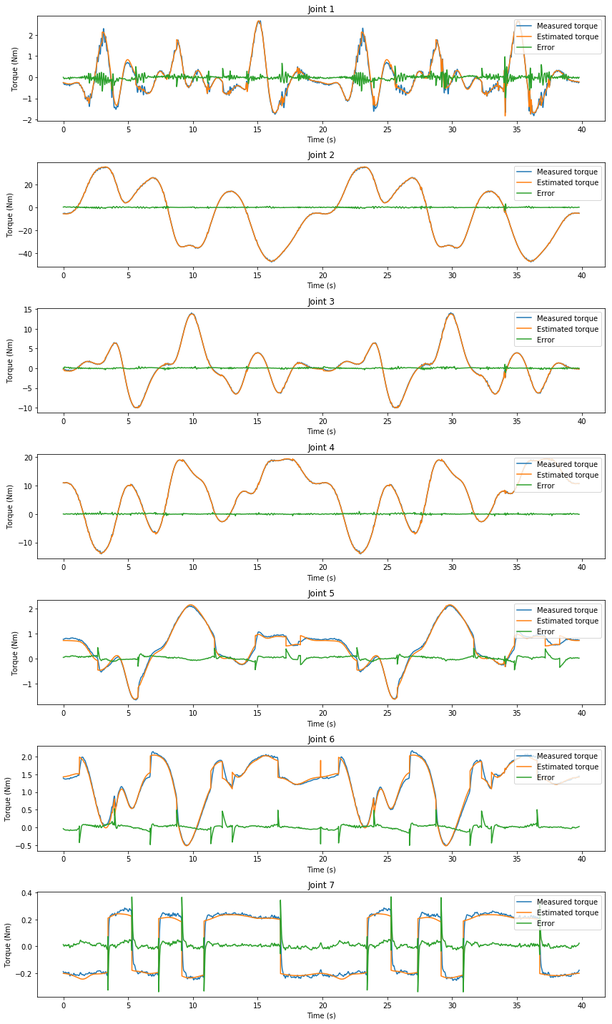

```python
from matplotlib import pyplot as plt
plt.close()

plt.figure(figsize=(12,20))
axes = []
for i in range(tau.shape[1]):
    ax = plt.subplot(7, 1, i+1)
#     ax.plot(t[:valid_data_num],tau_raw[:,i][:valid_data_num], label="Measured torque")
    ax.plot(t[:valid_data_num],tau_proc[:,i][:valid_data_num], label="Measured torque")
    ax.plot(t[:valid_data_num],tau_pred[:,i][:valid_data_num], label="Estimated torque")
    ax.plot(t[:valid_data_num],err_pred_proc[:,i][:valid_data_num], label="Error")
    ax.legend(loc='upper right',fontsize=10)
    ax.set_title( "Joint %d"%(i+1) )
    plt.xlabel("Time (s)")
    plt.ylabel("Torque (Nm)")
    axes.append(ax)

plt.tight_layout()
save_fig_path = tmpfolder + 'solutions/fig/' + robot_name+ '_' +traj + '_valid_result.png'
plt.savefig(save_fig_path)
plt.show()
```

```python
delta_starextra = Pb*beta_starextra + (-Pb*rbt.dyn.Kd+rbt.dyn.Pd)*delta_d_starextra
```

$$\beta^\star = K\ \delta^\star$$ $$\delta^\star_{min} = pinv(K)\ \beta^\star$$ $$K\ \delta^\star_{min} == K\ \delta^\star$$

```python
beta_data = numpy.matrix(numpy.loadtxt(tmpfolder + 'solutions/'+robot_name+'_traj1_beta_starextra.dat')).T
delta_data = numpy.matrix(numpy.loadtxt(tmpfolder + 'solutions/'+robot_name+'_traj1_delta_starextra.dat')).T

K = np.matrix(Pb.T+rbt.dyn.Kd*rbt.dyn.Pd.T).astype(float)
delta_data_min = np.linalg.pinv(K)*beta_data
numpy.savetxt(tmpfolder + 'solutions/'+robot_name+'_' + indentification_traj + '_delta_data_min.dat', delta_data_min)

# delta_data_min = numpy.matrix(numpy.loadtxt(tmpfolder + 'solutions/V1_traj1_delta_starextra.dat')).T
```

```python
np.testing.assert_array_almost_equal(K * delta_starextra ,beta_starextra, 10)
```

## Change Parameters set order to Matlab version

```python
# franka(no including Ia identification but including friction)
parms = [0]*rbt.dyn.n_dynparms
for i in range(rbt.dof):
    parms[i*12] = delta_data.tolist()[i*12]
    parms[i*12+1] = delta_data.tolist()[i*12+1]
    parms[i*12+2] = delta_data.tolist()[i*12+2]
    parms[i*12+3] = delta_data.tolist()[i*12+3]
    parms[i*12+4] = delta_data.tolist()[i*12+4]
    parms[i*12+5] = delta_data.tolist()[i*12+5]
    parms[i*12+6] = delta_data.tolist()[i*12+6]    # the link first moment of inertia
    parms[i*12+7] = delta_data.tolist()[i*12+7]    # the link first moment of inertia
    parms[i*12+8] = delta_data.tolist()[i*12+8]    # the link first moment of inertia
    parms[i*12+9] = delta_data.tolist()[i*12+9]
    parms[i*12+10] = delta_data.tolist()[i*12+10]
    parms[i*12+11] = delta_data.tolist()[i*12+11]

# list_txt(path=trajectory_folder+'opt_x.txt', list=opt_x)
f1 = open(tmpfolder + 'solutions/params.txt','w')
for j in parms:
    f1.write(str(j[0])+'\n')
f1.close()

result_data = numpy.loadtxt(tmpfolder + 'solutions/params.txt')
f2 = open(tmpfolder + 'solutions/matlab_s_function_params.txt','w')
for index,data in enumerate(result_data):
    f2.write(str(data)+', ')
    if(((index+1) % 12)==0):
        f2.write('\n')
f2.close()


for i in range(rbt.dof):
    result_data[i*12+6] = result_data[i*12+6]/result_data[i*12+9]    # the link first moment of inertia
    result_data[i*12+7] = result_data[i*12+7]/result_data[i*12+9]    # the link first moment of inertia
    result_data[i*12+8] = result_data[i*12+8]/result_data[i*12+9]    # the link first moment of inertia

np.savetxt(tmpfolder + 'solutions/params.txt', result_data)
```

### (generate readme and notebook preview)

```python
def save_files():
    from IPython.display import display, Javascript
    Javascript('IPython.notebook.save_notebook()')

    import json
    with open('General Robot Dynamic Parameter Identification.ipynb', 'r') as f:
        d = json.load(f)
    with open('README.md', 'w') as f:
        f.write(''.join(d['worksheets'][0]['cells'][0]['source']).encode('UTF-8'))

    !ipython nbconvert "General Robot Dynamic Parameter Identification.ipynb" --to html
```

```python
# save_files()
```

```python
#!git status
```

```python
#!git commit -a -m "Add automathic README.md file generator"
```

```python
#!git push
```